# Deep Learning Project

## Flowers Images Classification

Davide Giardini - 897473

# Import libraries

```python
import torch
torch.cuda.is_available()
```

```
True
```

```python
# Import TensorFlow/Keras
import tensorflow as tf
from tensorflow import keras
# keras.__version__
from time import time
import numpy as np
import random as python_random
# Import other modules
from matplotlib import pyplot as plt
np.random.seed(0)
python_random.seed(0)
tf.random.set_seed(0)
```

# Preprocessing

## Evaluation of average image size

```python
import cv2
import os
from tqdm import tqdm
```

```python
base_path = 'C:/Users/david/Desktop/DeepLearning/flower_photos'
categories = os.listdir(base_path)
categories
```

```
['daisy', 'dandelion', 'roses', 'sunflowers', 'Test', 'Train', 'tulips']
```

```python
height = []
width = []
for category in categories:
  for image in tqdm(os.listdir(base_path + category)):
    im = cv2.imread(base_path + category + '/' + image)
    height.append(im.shape[0])
    width.append(im.shape[1])
```

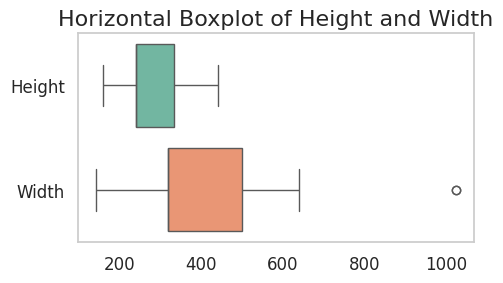

```python
# Setting up Seaborn style
sns.set(style="whitegrid")

# Creating horizontal boxplots
plt.figure(figsize=(5, 3))
g = sns.boxplot(data=[height, width], orient='h', palette='Set2')
plt.title('Horizontal Boxplot of Height and Width', fontsize=16)
plt.xticks(fontsize=12)
plt.yticks(fontsize=12)
g.set_yticklabels(['Height', 'Width'])
plt.grid(axis='x')
plt.tight_layout()
plt.show()
```

```python
# Average width
sum(width)/len(width)
```

```
365.0623978201635
```

```python
# Average height
sum(height)/len(height)
```

```
271.79128065395093
```

## Import data

We create two copies of the data, one named "Train" and one named "Test".

```python
train_path = 'C:/Users/david/Desktop/DeepLearning/flower_photos/Train/'
```

```python
train_dataset = keras.preprocessing.image_dataset_from_directory(train_path,
                                                            image_size=(256,256),
                                                            batch_size=32,
                                                            label_mode='categorical',
                                                            subset='training',
                                                            validation_split = 0.2,
                                                            shuffle=True,
                                                            seed=1)
```

```
Found 2936 files belonging to 5 classes.
Using 2349 files for training.
```

```python
val_dataset = keras.preprocessing.image_dataset_from_directory(train_path,
                                                            image_size=(256,256),
                                                            batch_size=32,
                                                            label_mode='categorical',
                                                            subset='validation',
                                                            validation_split = 0.2,
                                                            shuffle=True,
                                                            seed=1)
```

```
Found 2936 files belonging to 5 classes.
Using 587 files for validation.
```

## Split Train and Test folder

From the train data, we are going to remove all of the observations that have been selected in the validation dataset. In the same way, from the test data, we are going to remove all of the observations that have been selected in the train dataset.

```python
# From train dataset, remove all of the observations selected in validation set
for el in val_dataset.file_paths:
  os.remove(el)
```

```python
import re
```

```python
# From test dataset, remove all of the observations selected in train set
for el in train_dataset.file_paths:
  # Substitute 'Train' with 'Test' in order to remove observation from train directory
  el = re.sub('Train', 'Test', el)
  os.remove(el)
```

## A look at the data

```python
import os
train_path = 'C:/Users/david/Desktop/DeepLearning/flower_photos/Train/'
subD = os.listdir(train_path)
dizTrain = {}
# For each class subdirectory, insert in the dictionary dizTrain the number of element in that subdirectory
for dir in subD:
    dizTrain[dir] = len(os.listdir(train_path + dir))
```

```python
# Number of observations of each class in train set
dizTrain
```

```
{'daisy': 508,
 'dandelion': 701,
 'roses': 534,
 'sunflowers': 561,
 'tulips': 632}
```

```python
test_path = 'C:/Users/david/Desktop/DeepLearning/flower_photos/Test/'
subD = os.listdir(test_path)
dizTest = {}
# For each class subdirectory, insert in the dictionary dizTrain the number of element in that subdirectory
for dir in subD:
    dizTest[dir] = len(os.listdir(test_path + dir))
```

```python
# Number of observations of each class in train set
dizTest
```

```
{'daisy': 125,
 'dandelion': 197,
 'roses': 107,
 'sunflowers': 138,
 'tulips': 167}
```

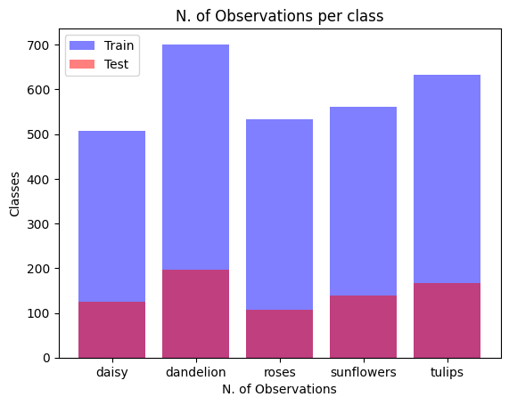

```python
plt.bar(dizTrain.keys(), dizTrain.values(), color='b', alpha=0.5, label='Train')
plt.bar(dizTest.keys(), dizTest.values(), color='r', alpha=0.5, label='Test')

# Adding labels and title
plt.xlabel('N. of Observations')
plt.ylabel('Classes')
plt.title('N. of Observations per class')
plt.legend()

# Show plot
plt.show()
```

As we can see, there is not a huge difference in the classes sizes. For now, we are going to try and develop CNNs that do not address the issues of unbalanced classes.

# Import data and split between train and Validation

[figure not shown]

```python
train_path = 'C:/Users/david/Desktop/DeepLearning/flower_photos/Train/'
test_path = 'C:/Users/david/Desktop/DeepLearning/flower_photos/Test/'
```

```python
train_ds = keras.preprocessing.image_dataset_from_directory(train_path,
                                                            image_size=(224,224),
                                                            batch_size=32,
                                                            label_mode='categorical',
                                                            subset='training',
                                                            validation_split = 0.2,
                                                            shuffle=True,
                                                            seed=1)
```

```
Found 2936 files belonging to 5 classes.
Using 2349 files for training.
```

```python
val_ds = keras.preprocessing.image_dataset_from_directory(train_path,
                                                            image_size=(224,224),
                                                            batch_size=32,
                                                            label_mode='categorical',
                                                            subset='validation',
                                                            validation_split = 0.2,
                                                            shuffle=True,
                                                            seed=1)
```

```
Found 2936 files belonging to 5 classes.
Using 587 files for validation.
```

```python
test_ds = keras.preprocessing.image_dataset_from_directory(test_path,
                                                            image_size=(224,224),
                                                            batch_size=32,
                                                            label_mode='categorical',
                                                            shuffle=False,
                                                            seed=1)
```

```
Found 734 files belonging to 5 classes.
```

```python
num_classes = 5
```

# First Models

We are going to start with a very easy CNN, and see what changes benefit its performances.

The first CNN consists of two hidden layers, with 32 and 64 neurons respectively. Both layers with ReLU activation.  
Max Pooling is applied to the first layer, and Global Max Pooling to the second.

```python
# Architecture definition Naive Model
inputs = keras.Input((224,224,3))

x = inputs
x = keras.layers.Conv2D(32, 3, padding="same")(x)
x = keras.layers.Activation("relu")(x)
x = keras.layers.MaxPooling2D(3, strides=3, padding="same")(x)

x = keras.layers.Conv2D(64, 3, padding="same")(x)
x = keras.layers.Activation("relu")(x)

x = keras.layers.GlobalMaxPooling2D()(x)

outputs = keras.layers.Dense(num_classes, activation="softmax")(x)
net = keras.Model(inputs, outputs)
```

```python
# Compile the model for training
net.compile(loss=keras.losses.categorical_crossentropy,
            optimizer=keras.optimizers.RMSprop(learning_rate=0.001),
            metrics=['accuracy'])
```

```python
# Check that we are running on GPU
tf.config.list_physical_devices('GPU')
```

```
[PhysicalDevice(name='/physical_device:GPU:0', device_type='GPU')]
```

```python
# Model training
history = net.fit(train_ds,
          epochs=40,
          validation_data=val_ds)
```

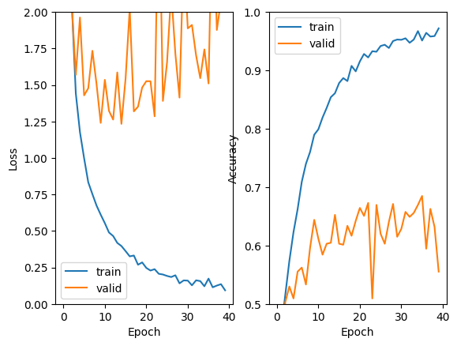

```python
# Visualization of the learning curves

plt.subplot(1, 2, 1)
plt.plot(history.history['loss'])
plt.plot(history.history['val_loss'])
plt.ylim([0.0, 2.0])
plt.xlabel('Epoch')
plt.ylabel('Loss')
plt.legend(['train', 'valid'])

plt.subplot(1, 2, 2)
plt.plot(history.history['accuracy'])
plt.plot(history.history['val_accuracy'])
plt.ylim([0.5, 1.0])
plt.xlabel('Epoch')
plt.ylabel('Accuracy')
plt.legend(['train', 'valid'])
```

While this simple Convolutional Neural Network reaches +95% accuracy on the training set, it is evident that it does not generalize well on the validation set. We will have to find additional methods to close the gap between train accuracy and validation accuracy.

## Batch Normalization

The process of batch normalization makes it so that the weight in the network do not become unbalanced. We are going to add Batch Normalization on both of the hidden layers of the network.

```python
# Architecture definition
inputs = keras.Input((224,224,3))

x = inputs
x = keras.layers.Conv2D(32, 3, padding="same")(x)
x = keras.layers.BatchNormalization()(x)
x = keras.layers.Activation("relu")(x)
x = keras.layers.MaxPooling2D(3, strides=3, padding="same")(x)

x = keras.layers.Conv2D(64, 3, padding="same")(x)
x = keras.layers.BatchNormalization()(x)
x = keras.layers.Activation("relu")(x)

x = keras.layers.GlobalMaxPooling2D()(x)

outputs = keras.layers.Dense(num_classes, activation="softmax")(x)
net = keras.Model(inputs, outputs)
```

```python
# Compile the model for training
net.compile(loss=keras.losses.categorical_crossentropy,
            optimizer=keras.optimizers.RMSprop(learning_rate=0.001),
            metrics=['accuracy'])
```

```python
# Model training (v2)
history = net.fit(train_ds,
          epochs=40,
          validation_data=val_ds);
```

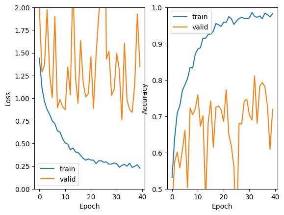

```python
# Visualization of the learning curves

plt.subplot(1, 2, 1)
plt.plot(history.history['loss'])
plt.plot(history.history['val_loss'])
plt.ylim([0.0, 2.0])
plt.xlabel('Epoch')
plt.ylabel('Loss')
plt.legend(['train', 'valid'])

plt.subplot(1, 2, 2)
plt.plot(history.history['accuracy'])
plt.plot(history.history['val_accuracy'])
plt.ylim([0.5, 1.0])
plt.xlabel('Epoch')
plt.ylabel('Accuracy')
plt.legend(['train', 'valid'])
```

It seems that adding batch Normalization results in an increase in performance.  
Though, there is a lot of volatility, and the network is still not able to generalize as well as we would want. In order to try and reduce this gap, we are going to add Data Augmentation.

# Data Augmentation

Data Augmentation consists in artificially augmenting the training data by, in this case, applying transformations over the observations. This will not only increase the size of the training data, but will increase its complexity. This increase in complexity will likely prevent overfitting, but will come at the cost of worse performances on the training data. This is not a problem, since, in case this happen, we can resolve the issue be increasing the complexity of our Neural Network.

Since we want to apply a "crop" augmentation, we have to re-import the training that as larger images, in order to later crop them into the default 224x224 size that we used for the previous CNNs.

```python
# Data loader with (slightly) larger images
# In this way, we can augment the images with RandomCrop
train_ds_256 = keras.preprocessing.image_dataset_from_directory(train_path,
                                                            image_size=(256,256),
                                                            batch_size=32,
                                                            label_mode='categorical',
                                                            subset='training',
                                                            validation_split = 0.2,
                                                            shuffle=True,
                                                            seed=1)
```

```
Found 2936 files belonging to 5 classes.
Using 2349 files for training.
```

```python
# We check if the file did not change. This should be the case since we inserted the same seed.
train_ds.file_paths == train_ds_256.file_paths
```

```
True
```

For augmenting our data, we apply three functions: RandomCrop, RandomFlip and RandomContrast. Note: these 3 types of augmentation have been decided via testing different combinations, for shortness and clarity purposes I'm not going to display all of them.  
For what regards everything else, the architechture will remain exactly the same. In this way we are going to test the improvements that this technique brings.

```python
# Architecture definition
inputs = keras.Input((None,None,3))

x = inputs

x = keras.layers.RandomCrop(224, 224)(x)
x = keras.layers.RandomFlip(mode='horizontal')(x)
x = keras.layers.RandomContrast(0.25)(x)

x = keras.layers.Conv2D(32, 3, padding="same")(x)
x = keras.layers.BatchNormalization()(x)
x = keras.layers.Activation("relu")(x)
x = keras.layers.MaxPooling2D(3, strides=3, padding="same")(x)

x = keras.layers.Conv2D(64, 3, padding="same")(x)
x = keras.layers.BatchNormalization()(x)
x = keras.layers.Activation("relu")(x)

x = keras.layers.GlobalMaxPooling2D()(x)

outputs = keras.layers.Dense(num_classes, activation="softmax")(x)
net = keras.Model(inputs, outputs)
```

```python
# Compile the model for training
net.compile(loss=keras.losses.categorical_crossentropy,
            optimizer=keras.optimizers.RMSprop(learning_rate=0.001),
            metrics=['accuracy'])
```

```python
# Model training
history = net.fit(train_ds_256,
          epochs=40,
          validation_data=val_ds)
```

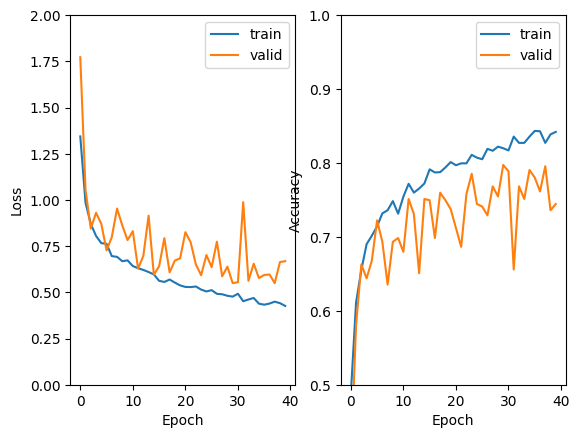

```python
# Visualization of the learning curves

plt.subplot(1, 2, 1)
plt.plot(history.history['loss'])
plt.plot(history.history['val_loss'])
plt.ylim([0.0, 2.0])
plt.xlabel('Epoch')
plt.ylabel('Loss')
plt.legend(['train', 'valid'])

plt.subplot(1, 2, 2)
plt.plot(history.history['accuracy'])
plt.plot(history.history['val_accuracy'])
plt.ylim([0.5, 1.0])
plt.xlabel('Epoch')
plt.ylabel('Accuracy')
plt.legend(['train', 'valid'])
```

Data augmentation did lower the accuracy on the training set, partially resolving the overfitting problem of the model. Though, we have a really high volatilty on the validation set, we are going to try to address this by lowering the Learning Rate.

## Lower Learning Rate

```python
inputs = keras.Input((None,None,3))

x = inputs

x = keras.layers.RandomCrop(224, 224)(x)
x = keras.layers.RandomFlip(mode='horizontal')(x)
x = keras.layers.RandomContrast(0.25)(x)

x = keras.layers.Conv2D(32, 3, padding="same")(x)
x = keras.layers.BatchNormalization()(x)
x = keras.layers.Activation("relu")(x)
x = keras.layers.MaxPooling2D(3, strides=3, padding="same")(x)

x = keras.layers.Conv2D(64, 3, padding="same")(x)
x = keras.layers.BatchNormalization()(x)
x = keras.layers.Activation("relu")(x)

x = keras.layers.GlobalMaxPooling2D()(x)

outputs = keras.layers.Dense(num_classes, activation="softmax")(x)
net = keras.Model(inputs, outputs)
```

```python
# Compile the model for training
net.compile(loss=keras.losses.categorical_crossentropy,
            optimizer=keras.optimizers.RMSprop(learning_rate=0.0005),
            metrics=['accuracy'])
```

```python
# Model training (v4)
history = net.fit(train_ds_256,
          epochs=40,
          validation_data=val_ds)
```

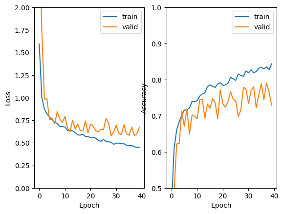

```python
# Visualization of the learning curves

plt.subplot(1, 2, 1)
plt.plot(history.history['loss'])
plt.plot(history.history['val_loss'])
plt.ylim([0.0, 2.0])
plt.xlabel('Epoch')
plt.ylabel('Loss')
plt.legend(['train', 'valid'])

plt.subplot(1, 2, 2)
plt.plot(history.history['accuracy'])
plt.plot(history.history['val_accuracy'])
plt.ylim([0.5, 1.0])
plt.xlabel('Epoch')
plt.ylabel('Accuracy')
plt.legend(['train', 'valid'])
```

The volatility in the validation set did decrease a little, though, it is still present. Another possible cause of this could be that we chose a validation set that is too small. By choosing a small validation set, it could be possible that, at each epoch, the changes in the weights of the model that occur influence the classification of a big portion of the observation. We are going to try to see if, by increasing the validation set to a 30%, the validation accuracy is going to result more stable.

## Change validation-set size from 20% to 30%

The train data is going to be split in 70% train set and 30% validation set. The test data is not going to be touched.  
To recap: we firstly split the entire dataset in 80% train and 20% test. Now, we split the train set in 70% train and 30% validation. In this way, we have 0.56% train + 0.24% validation + 20% test.

```python
train_ds = keras.preprocessing.image_dataset_from_directory(train_path,
                                                            image_size=(224,224),
                                                            batch_size=32,
                                                            label_mode='categorical',
                                                            subset='training',
                                                            validation_split = 0.3,
                                                            shuffle=True,
                                                            seed=1)

val_ds = keras.preprocessing.image_dataset_from_directory(train_path,
                                                            image_size=(224,224),
                                                            batch_size=32,
                                                            label_mode='categorical',
                                                            subset='validation',
                                                            validation_split = 0.3,
                                                            shuffle=True,
                                                            seed=1)

# Data loader with (slightly) larger images
# In this way, we can augment the images with RandomCrop
train_ds_256 = keras.preprocessing.image_dataset_from_directory(train_path,
                                                            image_size=(256,256),
                                                            batch_size=32,
                                                            label_mode='categorical',
                                                            subset='training',
                                                            validation_split = 0.3,
                                                            shuffle=True,
                                                            seed=1)
```

```
Found 2936 files belonging to 5 classes.
Using 2056 files for training.
Found 2936 files belonging to 5 classes.
Using 880 files for validation.
Found 2936 files belonging to 5 classes.
Using 2056 files for training.
```

```python
# We check if the file did not change. This should be the case since we inserted the same seed.
train_ds.file_paths == train_ds_256.file_paths
```

```
True
```

We are now going to retrain the exact same model, in order to evaluate the effects that this change in train/validation proportion have caused.

```python
inputs = keras.Input((None,None,3))

x = inputs

x = keras.layers.RandomCrop(224, 224)(x)
x = keras.layers.RandomFlip(mode='horizontal')(x)
x = keras.layers.RandomContrast(0.25)(x)

x = keras.layers.Conv2D(32, 3, padding="same")(x)
x = keras.layers.BatchNormalization()(x)
x = keras.layers.Activation("relu")(x)
x = keras.layers.MaxPooling2D(3, strides=3, padding="same")(x)

x = keras.layers.Conv2D(64, 3, padding="same")(x)
x = keras.layers.BatchNormalization()(x)
x = keras.layers.Activation("relu")(x)

x = keras.layers.GlobalMaxPooling2D()(x)

outputs = keras.layers.Dense(num_classes, activation="softmax")(x)
net = keras.Model(inputs, outputs)
```

```python
# Compile the model for training
net.compile(loss=keras.losses.categorical_crossentropy,
            optimizer=keras.optimizers.RMSprop(learning_rate=0.0005),
            metrics=['accuracy'])
```

```python
# Model training (v4)
history = net.fit(train_ds_256,
          epochs=40,
          validation_data=val_ds)
```

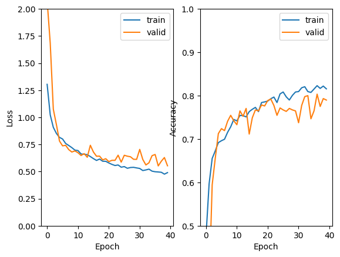

```python
# Visualization of the learning curves

plt.subplot(1, 2, 1)
plt.plot(history.history['loss'])
plt.plot(history.history['val_loss'])
plt.ylim([0.0, 2.0])
plt.xlabel('Epoch')
plt.ylabel('Loss')
plt.legend(['train', 'valid'])

plt.subplot(1, 2, 2)
plt.plot(history.history['accuracy'])
plt.plot(history.history['val_accuracy'])
plt.ylim([0.5, 1.0])
plt.xlabel('Epoch')
plt.ylabel('Accuracy')
plt.legend(['train', 'valid'])
```

The validation accuracy seems more stable than before.  
In conclusion: as we expected, data augmentation partially resolves the problem of over fitting, and achieves better validation accuracy. This of course came at the cost of lower performances on the training set. We will tackle this issue by increasing the model complexity.

## Deeper CNN

As a first thing, we are going to add a third hidden layer of 128 neurons.

```python
# Architecture definition
inputs = keras.Input((None,None,3))

x = inputs

x = keras.layers.RandomCrop(224, 224)(x)
x = keras.layers.RandomFlip(mode='horizontal')(x)
x = keras.layers.RandomContrast(0.25)(x)

x = keras.layers.Conv2D(32, 3, padding="same")(x)
x = keras.layers.BatchNormalization()(x)
x = keras.layers.Activation("relu")(x)
x = keras.layers.MaxPooling2D(3, strides=3, padding="same")(x)

x = keras.layers.Conv2D(64, 3, padding="same")(x)
x = keras.layers.BatchNormalization()(x)
x = keras.layers.Activation("relu")(x)
x = keras.layers.MaxPooling2D(3, strides=3, padding="same")(x)

x = keras.layers.Conv2D(128, 3, padding="same")(x)
x = keras.layers.BatchNormalization()(x)
x = keras.layers.Activation("relu")(x)

x = keras.layers.GlobalMaxPooling2D()(x)

outputs = keras.layers.Dense(num_classes, activation="softmax")(x)
net = keras.Model(inputs, outputs)
```

```python
# Compile the model for training
net.compile(loss=keras.losses.categorical_crossentropy,
            optimizer=keras.optimizers.RMSprop(learning_rate=0.0005),
            metrics=['accuracy'])
```

```python
# Model training
history = net.fit(train_ds_256,
          epochs=40,
          validation_data=val_ds)
```

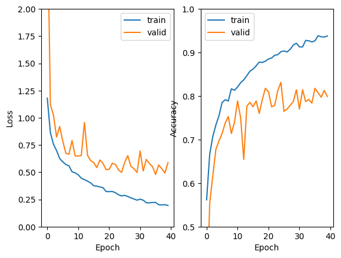

```python
# Visualization of the learning curves

plt.subplot(1, 2, 1)
plt.plot(history.history['loss'])
plt.plot(history.history['val_loss'])
plt.ylim([0.0, 2.0])
plt.xlabel('Epoch')
plt.ylabel('Loss')
plt.legend(['train', 'valid'])

plt.subplot(1, 2, 2)
plt.plot(history.history['accuracy'])
plt.plot(history.history['val_accuracy'])
plt.ylim([0.5, 1.0])
plt.xlabel('Epoch')
plt.ylabel('Accuracy')
plt.legend(['train', 'valid'])
```

To fights this variability in validation accuracy as the epoches pass, we are going to introduce a time-decaying learning rate.

## TimeDecay

```python
# Architecture definition
inputs = keras.Input((None,None,3))

x = inputs

x = keras.layers.RandomCrop(224, 224)(x)
x = keras.layers.RandomFlip(mode='horizontal')(x)
x = keras.layers.RandomContrast(0.25)(x)

x = keras.layers.Conv2D(32, 3, padding="same")(x)
x = keras.layers.BatchNormalization()(x)
x = keras.layers.Activation("relu")(x)
x = keras.layers.MaxPooling2D(3, strides=3, padding="same")(x)

x = keras.layers.Conv2D(64, 3, padding="same")(x)
x = keras.layers.BatchNormalization()(x)
x = keras.layers.Activation("relu")(x)
x = keras.layers.MaxPooling2D(3, strides=3, padding="same")(x)

x = keras.layers.Conv2D(128, 3, padding="same")(x)
x = keras.layers.BatchNormalization()(x)
x = keras.layers.Activation("relu")(x)

x = keras.layers.GlobalMaxPooling2D()(x)

outputs = keras.layers.Dense(num_classes, activation="softmax")(x)
net = keras.Model(inputs, outputs)
```

```python
callback = keras.callbacks.EarlyStopping(monitor='val_loss', patience=10)
```

```python
lr_schedule = keras.optimizers.schedules.InverseTimeDecay(
    initial_learning_rate = 0.0005,
    decay_steps = 65,
    decay_rate = 0.08)
optimizer = keras.optimizers.RMSprop(learning_rate=lr_schedule)
net.compile(loss=keras.losses.categorical_crossentropy,
            optimizer=optimizer,
            metrics=['accuracy'])
```

```python
# Model training
history = net.fit(train_ds_256,
          epochs=80,
          validation_data=val_ds,
            callbacks=[callback])
```

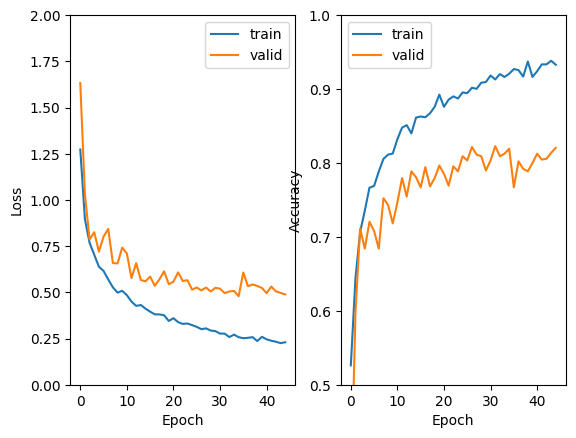

```python
# Visualization of the learning curves

plt.subplot(1, 2, 1)
plt.plot(history.history['loss'])
plt.plot(history.history['val_loss'])
plt.ylim([0.0, 2.0])
plt.xlabel('Epoch')
plt.ylabel('Loss')
plt.legend(['train', 'valid'])

plt.subplot(1, 2, 2)
plt.plot(history.history['accuracy'])
plt.plot(history.history['val_accuracy'])
plt.ylim([0.5, 1.0])
plt.xlabel('Epoch')
plt.ylabel('Accuracy')
plt.legend(['train', 'valid'])
```

The addition of the Time-decaying Learning Rate helped to increase the accuracy of the validation set even at higher epochs.

## Adam optimizer

```python
# Architecture definition
inputs = keras.Input((None,None,3))

x = inputs

x = keras.layers.RandomCrop(224, 224)(x)
x = keras.layers.RandomFlip(mode='horizontal')(x)
x = keras.layers.RandomContrast(0.25)(x)

x = keras.layers.Conv2D(32, 3, padding="same")(x)
x = keras.layers.BatchNormalization()(x)
x = keras.layers.Activation("relu")(x)
x = keras.layers.MaxPooling2D(3, strides=3, padding="same")(x)

x = keras.layers.Conv2D(64, 3, padding="same")(x)
x = keras.layers.BatchNormalization()(x)
x = keras.layers.Activation("relu")(x)
x = keras.layers.MaxPooling2D(3, strides=3, padding="same")(x)

x = keras.layers.Conv2D(128, 3, padding="same")(x)
x = keras.layers.BatchNormalization()(x)
x = keras.layers.Activation("relu")(x)

x = keras.layers.GlobalMaxPooling2D()(x)

outputs = keras.layers.Dense(num_classes, activation="softmax")(x)
net = keras.Model(inputs, outputs)
```

```python
callback = keras.callbacks.EarlyStopping(monitor='val_loss', patience=10)
```

```python
lr_schedule = keras.optimizers.schedules.InverseTimeDecay(
    initial_learning_rate = 0.0005,
    decay_steps = 65,
    decay_rate = 0.08)
optimizer = keras.optimizers.Adam(learning_rate=lr_schedule)
net.compile(loss=keras.losses.categorical_crossentropy,
            optimizer=optimizer,
            metrics=['accuracy'])
```

```python
# Model training
history = net.fit(train_ds_256,
          epochs=80,
          validation_data=val_ds,
            callbacks=[callback])
```

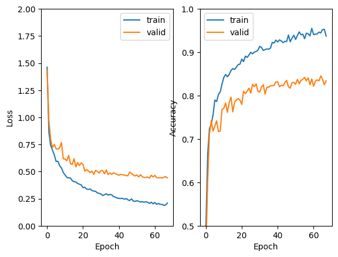

```python
# Visualization of the learning curves

plt.subplot(1, 2, 1)
plt.plot(history.history['loss'])
plt.plot(history.history['val_loss'])
plt.ylim([0.0, 2.0])
plt.xlabel('Epoch')
plt.ylabel('Loss')
plt.legend(['train', 'valid'])

plt.subplot(1, 2, 2)
plt.plot(history.history['accuracy'])
plt.plot(history.history['val_accuracy'])
plt.ylim([0.5, 1.0])
plt.xlabel('Epoch')
plt.ylabel('Accuracy')
plt.legend(['train', 'valid'])
```

By changing the optimizer to Adam, we have a notable increase in validation accuracy.  
Even though the model is not technically overfitting, since the two curves are not diverging, we are going to test some Regularization methods. We do this in the hope that, by closing the gap between validation and train, we will be able to increase the validation accuracy further.

### Try Regularizer

#### 0.001

```python
# Architecture definition
inputs = keras.Input((None,None,3))

x = inputs

x = keras.layers.RandomCrop(224, 224)(x)
x = keras.layers.RandomFlip(mode='horizontal')(x)
x = keras.layers.RandomContrast(0.25)(x)

x = keras.layers.Conv2D(32, 3, padding="same", kernel_regularizer=tf.keras.regularizers.l2(0.001))(x)
x = keras.layers.BatchNormalization()(x)
x = keras.layers.Activation("relu")(x)
x = keras.layers.MaxPooling2D(3, strides=3, padding="same")(x)

x = keras.layers.Conv2D(64, 3, padding="same", kernel_regularizer=tf.keras.regularizers.l2(0.001))(x)
x = keras.layers.BatchNormalization()(x)
x = keras.layers.Activation("relu")(x)
x = keras.layers.MaxPooling2D(3, strides=3, padding="same")(x)

x = keras.layers.Conv2D(128, 3, padding="same", kernel_regularizer=tf.keras.regularizers.l2(0.001))(x)
x = keras.layers.BatchNormalization()(x)
x = keras.layers.Activation("relu")(x)

x = keras.layers.GlobalMaxPooling2D()(x)

outputs = keras.layers.Dense(num_classes, activation="softmax", kernel_regularizer=tf.keras.regularizers.l2(0.001))(x)
net = keras.Model(inputs, outputs)
```

```python
callback = keras.callbacks.EarlyStopping(monitor='val_loss', patience=10)
```

```python
lr_schedule = keras.optimizers.schedules.InverseTimeDecay(
    initial_learning_rate = 0.0005,
    decay_steps = 65,
    decay_rate = 0.08)
optimizer = keras.optimizers.Adam(learning_rate=lr_schedule)
net.compile(loss=keras.losses.categorical_crossentropy,
            optimizer=optimizer,
            metrics=['accuracy'])
```

```python
# Model training
history = net.fit(train_ds_256,
          epochs=80,
          validation_data=val_ds,
            callbacks=[callback])
```

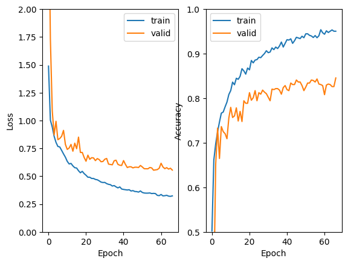

```python
# Visualization of the learning curves

plt.subplot(1, 2, 1)
plt.plot(history.history['loss'])
plt.plot(history.history['val_loss'])
plt.ylim([0.0, 2.0])
plt.xlabel('Epoch')
plt.ylabel('Loss')
plt.legend(['train', 'valid'])

plt.subplot(1, 2, 2)
plt.plot(history.history['accuracy'])
plt.plot(history.history['val_accuracy'])
plt.ylim([0.5, 1.0])
plt.xlabel('Epoch')
plt.ylabel('Accuracy')
plt.legend(['train', 'valid'])
```

The addition of a regularizer does not seem to benefit the model in a notable way. Other attempts were made (changing the parameter, using the L1 regularizer) but none of them brought a substantial improvement in the model quality. We are then going to try another regularization method: DropOut layers.

### DropOut

After Testing different combinations of Dropout layers, two were selected:

1. 0.1 Dropout on second layer + 0.2 Dropout on third layer
2. 0.1 Dropout on first layer + 0.2 Dropout on second layer + 0.3 Dropout on third layer

#### First combination (0.0 + 0.1 + 0.2)

```python
# Architecture definition
inputs = keras.Input((None,None,3))

x = inputs

x = keras.layers.RandomCrop(224, 224)(x)
x = keras.layers.RandomFlip(mode='horizontal')(x)
x = keras.layers.RandomContrast(0.25)(x)

x = keras.layers.Conv2D(32, 3, padding="same")(x)
x = keras.layers.BatchNormalization()(x)
x = keras.layers.Activation("relu")(x)
x = keras.layers.MaxPooling2D(3, strides=3, padding="same")(x)

x = keras.layers.Conv2D(64, 3, padding="same")(x)
x = keras.layers.BatchNormalization()(x)
x = keras.layers.Activation("relu")(x)
x = keras.layers.MaxPooling2D(3, strides=3, padding="same")(x)
x = keras.layers.Dropout(0.1)(x)

x = keras.layers.Conv2D(128, 3, padding="same")(x)
x = keras.layers.BatchNormalization()(x)
x = keras.layers.Activation("relu")(x)
x = keras.layers.Dropout(0.2)(x)

x = keras.layers.GlobalMaxPooling2D()(x)

outputs = keras.layers.Dense(num_classes, activation="softmax")(x)
net = keras.Model(inputs, outputs)
```

```python
callback = keras.callbacks.EarlyStopping(monitor='val_loss', patience=10)
```

```python
lr_schedule = keras.optimizers.schedules.InverseTimeDecay(
    initial_learning_rate = 0.0005,
    decay_steps = 65,
    decay_rate = 0.08)
optimizer = keras.optimizers.Adam(learning_rate=lr_schedule)
net.compile(loss=keras.losses.categorical_crossentropy,
            optimizer=optimizer,
            metrics=['accuracy'])
```

```python
# Model training
history = net.fit(train_ds_256,
          epochs=80,
          validation_data=val_ds,
            callbacks=[callback])
```

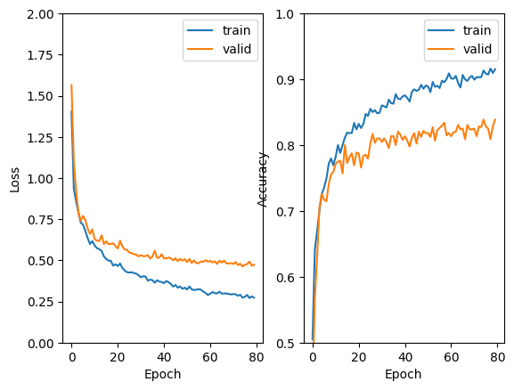

```python
# Visualization of the learning curves

plt.subplot(1, 2, 1)
plt.plot(history.history['loss'])
plt.plot(history.history['val_loss'])
plt.ylim([0.0, 2.0])
plt.xlabel('Epoch')
plt.ylabel('Loss')
plt.legend(['train', 'valid'])

plt.subplot(1, 2, 2)
plt.plot(history.history['accuracy'])
plt.plot(history.history['val_accuracy'])
plt.ylim([0.5, 1.0])
plt.xlabel('Epoch')
plt.ylabel('Accuracy')
plt.legend(['train', 'valid'])
```

```python
net.save("models/B3DropRMS.keras")
```

This combination of Dropout layers reduces the overfitting without affecting validation accuracy. There is a bit of a gap in train and validation accuracy, but the two curves do not diverge, demonstrating that, even if the model has better performances on train than on validation, the increase in train accuracy brings an increase also in validation accuracy. Since this is one of the best models we have, we are going to test its accuracy on the test set.

```python
net = keras.models.load_model("models/B3DropRMS.keras")
net.evaluate(test_ds)
```

```
[0.4477007985115051, 0.8365122675895691]
```

The test accuracy is of 83.65%. This is in line with the accuracy we had on validation set. We are going to compare this result with the one we achieve with a variant of the next combination.

#### Second Combination (0.1 + 0.2 + 0.3)

```python
# Architecture definition
inputs = keras.Input((None,None,3))

x = inputs

x = keras.layers.RandomCrop(224, 224)(x)
x = keras.layers.RandomFlip(mode='horizontal')(x)
x = keras.layers.RandomContrast(0.25)(x)

x = keras.layers.Conv2D(32, 3, padding="same")(x)
x = keras.layers.BatchNormalization()(x)
x = keras.layers.Activation("relu")(x)
x = keras.layers.MaxPooling2D(3, strides=3, padding="same")(x)
x = keras.layers.Dropout(0.1)(x)

x = keras.layers.Conv2D(64, 3, padding="same")(x)
x = keras.layers.BatchNormalization()(x)
x = keras.layers.Activation("relu")(x)
x = keras.layers.MaxPooling2D(3, strides=3, padding="same")(x)
x = keras.layers.Dropout(0.2)(x)

x = keras.layers.Conv2D(128, 3, padding="same")(x)
x = keras.layers.BatchNormalization()(x)
x = keras.layers.Activation("relu")(x)
x = keras.layers.Dropout(0.3)(x)

x = keras.layers.GlobalMaxPooling2D()(x)

outputs = keras.layers.Dense(num_classes, activation="softmax")(x)
net = keras.Model(inputs, outputs)
```

```python
callback = keras.callbacks.EarlyStopping(monitor='val_loss', patience=10)
```

```python
lr_schedule = keras.optimizers.schedules.InverseTimeDecay(
    initial_learning_rate = 0.0005,
    decay_steps = 65,
    decay_rate = 0.08)
optimizer = keras.optimizers.Adam(learning_rate=lr_schedule)
net.compile(loss=keras.losses.categorical_crossentropy,
            optimizer=optimizer,
            metrics=['accuracy'])
```

```python
# Model training
history = net.fit(train_ds_256,
          epochs=80,
          validation_data=val_ds,
            callbacks=[callback])
```

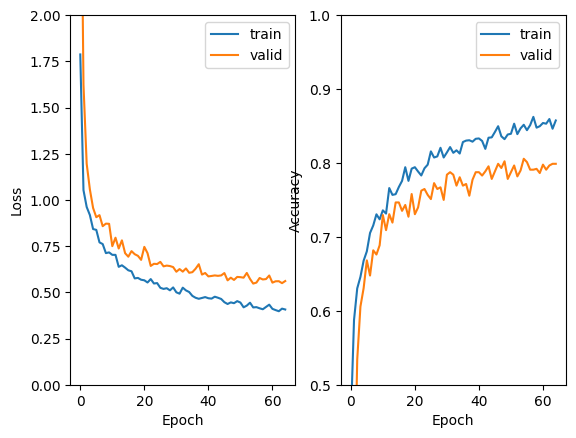

```python
# Visualization of the learning curves

plt.subplot(1, 2, 1)
plt.plot(history.history['loss'])
plt.plot(history.history['val_loss'])
plt.ylim([0.0, 2.0])
plt.xlabel('Epoch')
plt.ylabel('Loss')
plt.legend(['train', 'valid'])

plt.subplot(1, 2, 2)
plt.plot(history.history['accuracy'])
plt.plot(history.history['val_accuracy'])
plt.ylim([0.5, 1.0])
plt.xlabel('Epoch')
plt.ylabel('Accuracy')
plt.legend(['train', 'valid'])
```

```python
net.save("models/B3DropAv2.keras")
```

This second combination has stronger regularization power. In this way, the gap between train and validation is further decreased, but this time it does affect validation accuracy. What we can do, though, is deepening further the architechture of the model, in the hope that we can achieve the same (or better) validation accuracy but with a lower gap between train and validation.

## Further deepening the model

### Additional Dense Layer

```python
# Architecture definition
inputs = keras.Input((None,None,3))

x = inputs

x = keras.layers.RandomCrop(224, 224)(x)
x = keras.layers.RandomFlip(mode='horizontal')(x)
x = keras.layers.RandomContrast(0.25)(x)

x = keras.layers.Conv2D(32, 3, padding="same")(x)
x = keras.layers.BatchNormalization()(x)
x = keras.layers.Activation("relu")(x)
x = keras.layers.MaxPooling2D(3, strides=3, padding="same")(x)
x = keras.layers.Dropout(0.1)(x)

x = keras.layers.Conv2D(64, 3, padding="same")(x)
x = keras.layers.BatchNormalization()(x)
x = keras.layers.Activation("relu")(x)
x = keras.layers.MaxPooling2D(3, strides=3, padding="same")(x)
x = keras.layers.Dropout(0.2)(x)

x = keras.layers.Conv2D(128, 3, padding="same")(x)
x = keras.layers.BatchNormalization()(x)
x = keras.layers.Activation("relu")(x)
x = keras.layers.Dropout(0.3)(x)

x = keras.layers.GlobalMaxPooling2D()(x)

outputs = keras.layers.Dense(1024, activation="softmax")(x)

outputs = keras.layers.Dense(num_classes, activation="softmax")(x)
net = keras.Model(inputs, outputs)
```

```python
callback = keras.callbacks.EarlyStopping(monitor='val_loss', patience=10)
```

```python
lr_schedule = keras.optimizers.schedules.InverseTimeDecay(
    initial_learning_rate = 0.0005,
    decay_steps = 65,
    decay_rate = 0.08)
optimizer = keras.optimizers.Adam(learning_rate=lr_schedule)
net.compile(loss=keras.losses.categorical_crossentropy,
            optimizer=optimizer,
            metrics=['accuracy'])
```

```python
# Model training
history = net.fit(train_ds_256,
          epochs=80,
          validation_data=val_ds,
            callbacks=[callback])
```

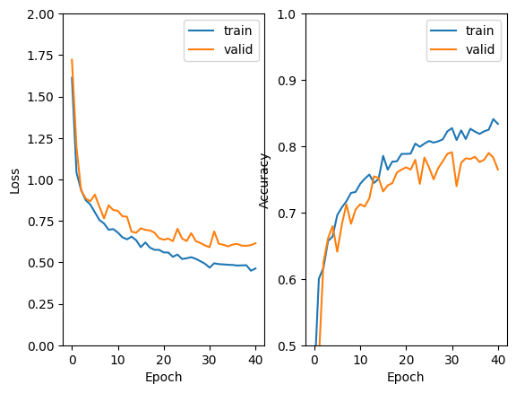

```python
# Visualization of the learning curves

plt.subplot(1, 2, 1)
plt.plot(history.history['loss'])
plt.plot(history.history['val_loss'])
plt.ylim([0.0, 2.0])
plt.xlabel('Epoch')
plt.ylabel('Loss')
plt.legend(['train', 'valid'])

plt.subplot(1, 2, 2)
plt.plot(history.history['accuracy'])
plt.plot(history.history['val_accuracy'])
plt.ylim([0.5, 1.0])
plt.xlabel('Epoch')
plt.ylabel('Accuracy')
plt.legend(['train', 'valid'])
```

### Changing the Convolutional Layer

We are going to try and remove the first convolutional layer of 32 neuron while adding a last layer of 256.

```python
# Architecture definition
inputs = keras.Input((None,None,3))

x = inputs

x = keras.layers.RandomCrop(224, 224)(x)
x = keras.layers.RandomFlip(mode='horizontal')(x)
x = keras.layers.RandomContrast(0.25)(x)

x = keras.layers.Conv2D(64, 3, padding="same")(x)
x = keras.layers.BatchNormalization()(x)
x = keras.layers.Activation("relu")(x)
x = keras.layers.MaxPooling2D(3, strides=3, padding="same")(x)
x = keras.layers.Dropout(0.1)(x)

x = keras.layers.Conv2D(128, 3, padding="same")(x)
x = keras.layers.BatchNormalization()(x)
x = keras.layers.Activation("relu")(x)
x = keras.layers.MaxPooling2D(3, strides=3, padding="same")(x)
x = keras.layers.Dropout(0.2)(x)

x = keras.layers.Conv2D(256, 3, padding="same")(x)
x = keras.layers.BatchNormalization()(x)
x = keras.layers.Activation("relu")(x)
x = keras.layers.Dropout(0.3)(x)

x = keras.layers.GlobalMaxPooling2D()(x)

outputs = keras.layers.Dense(1024, activation="softmax")(x)

outputs = keras.layers.Dense(num_classes, activation="softmax")(x)
net = keras.Model(inputs, outputs)
```

```python
callback = keras.callbacks.EarlyStopping(monitor='val_loss', patience=10)
```

```python
lr_schedule = keras.optimizers.schedules.InverseTimeDecay(
    initial_learning_rate = 0.0005,
    decay_steps = 65,
    decay_rate = 0.08)
optimizer = keras.optimizers.Adam(learning_rate=lr_schedule)
net.compile(loss=keras.losses.categorical_crossentropy,
            optimizer=optimizer,
            metrics=['accuracy'])
```

```python
# Model training
history = net.fit(train_ds_256,
          epochs=80,
          validation_data=val_ds,
            callbacks=[callback])
```

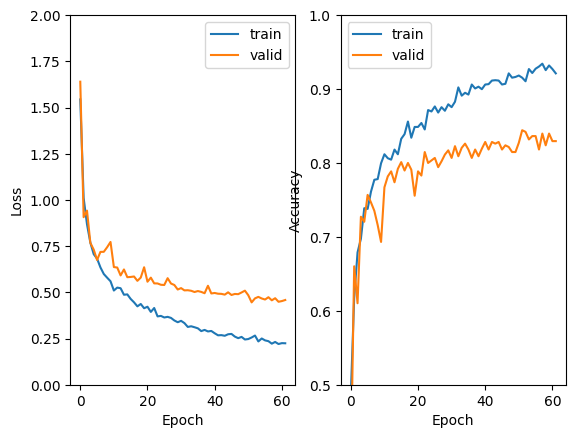

```python
# Visualization of the learning curves

plt.subplot(1, 2, 1)
plt.plot(history.history['loss'])
plt.plot(history.history['val_loss'])
plt.ylim([0.0, 2.0])
plt.xlabel('Epoch')
plt.ylabel('Loss')
plt.legend(['train', 'valid'])

plt.subplot(1, 2, 2)
plt.plot(history.history['accuracy'])
plt.plot(history.history['val_accuracy'])
plt.ylim([0.5, 1.0])
plt.xlabel('Epoch')
plt.ylabel('Accuracy')
plt.legend(['train', 'valid'])
```

```python
net.save("models/B64ADrop.keras")
```

This modification in the architechture does bring an improvement. Of course, since we have more neurons, we have (again) increased the gap between train and validation. After other testing, we came to this architechture: adding another dense layer of 512 and adding a Dropout layer to the first dense layer.

```python
# Architecture definition
inputs = keras.Input((None,None,3))

x = inputs

x = keras.layers.RandomCrop(224, 224)(x)
x = keras.layers.RandomFlip(mode='horizontal')(x)
x = keras.layers.RandomContrast(0.25)(x)

x = keras.layers.Conv2D(64, 3, padding="same")(x)
x = keras.layers.BatchNormalization()(x)
x = keras.layers.Activation("relu")(x)
x = keras.layers.MaxPooling2D(3, strides=3, padding="same")(x)
x = keras.layers.Dropout(0.1)(x)

x = keras.layers.Conv2D(128, 3, padding="same")(x)
x = keras.layers.BatchNormalization()(x)
x = keras.layers.Activation("relu")(x)
x = keras.layers.MaxPooling2D(3, strides=3, padding="same")(x)
x = keras.layers.Dropout(0.2)(x)

x = keras.layers.Conv2D(256, 3, padding="same")(x)
x = keras.layers.BatchNormalization()(x)
x = keras.layers.Activation("relu")(x)
x = keras.layers.Dropout(0.2)(x)

x = keras.layers.GlobalMaxPooling2D()(x)

outputs = keras.layers.Dense(1024, activation="softmax")(x)
x = keras.layers.Dropout(0.1)(x)

outputs = keras.layers.Dense(512, activation="softmax")(x)

outputs = keras.layers.Dense(num_classes, activation="softmax")(x)
net = keras.Model(inputs, outputs)
```

```python
callback = keras.callbacks.EarlyStopping(monitor='val_loss', patience=10)
```

```python
lr_schedule = keras.optimizers.schedules.InverseTimeDecay(
    initial_learning_rate = 0.0005,
    decay_steps = 65,
    decay_rate = 0.08)
optimizer = keras.optimizers.Adam(learning_rate=lr_schedule)
net.compile(loss=keras.losses.categorical_crossentropy,
            optimizer=optimizer,
            metrics=['accuracy'])
```

```python
# Model training
history = net.fit(train_ds_256,
          epochs=80,
          validation_data=val_ds,
            callbacks=[callback])
```

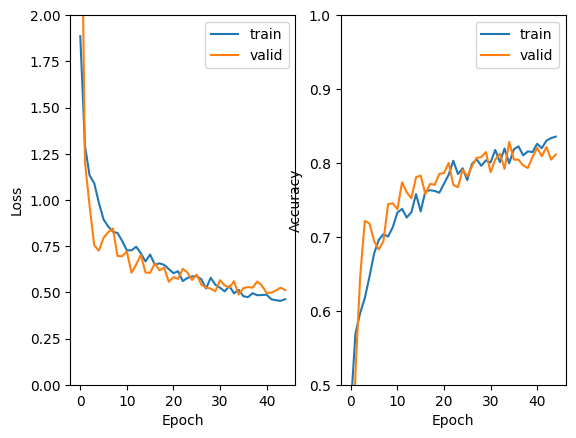

```python
# Visualization of the learning curves

plt.subplot(1, 2, 1)
plt.plot(history.history['loss'])
plt.plot(history.history['val_loss'])
plt.ylim([0.0, 2.0])
plt.xlabel('Epoch')
plt.ylabel('Loss')
plt.legend(['train', 'valid'])

plt.subplot(1, 2, 2)
plt.plot(history.history['accuracy'])
plt.plot(history.history['val_accuracy'])
plt.ylim([0.5, 1.0])
plt.xlabel('Epoch')
plt.ylabel('Accuracy')
plt.legend(['train', 'valid'])
```

By decreasing the strength of the dropout layer, we could be able to let the model learn more:

```python
# Architecture definition
inputs = keras.Input((None,None,3))

x = inputs

x = keras.layers.RandomCrop(224, 224)(x)
x = keras.layers.RandomFlip(mode='horizontal')(x)
x = keras.layers.RandomContrast(0.25)(x)

x = keras.layers.Conv2D(64, 3, padding="same")(x)
x = keras.layers.BatchNormalization()(x)
x = keras.layers.Activation("relu")(x)
x = keras.layers.MaxPooling2D(3, strides=3, padding="same")(x)
x = keras.layers.Dropout(0.1)(x)

x = keras.layers.Conv2D(128, 3, padding="same")(x)
x = keras.layers.BatchNormalization()(x)
x = keras.layers.Activation("relu")(x)
x = keras.layers.MaxPooling2D(3, strides=3, padding="same")(x)
x = keras.layers.Dropout(0.1)(x)

x = keras.layers.Conv2D(256, 3, padding="same")(x)
x = keras.layers.BatchNormalization()(x)
x = keras.layers.Activation("relu")(x)
x = keras.layers.Dropout(0.1)(x)

x = keras.layers.GlobalMaxPooling2D()(x)

outputs = keras.layers.Dense(1024, activation="softmax")(x)
x = keras.layers.Dropout(0.2)(x)

outputs = keras.layers.Dense(512, activation="softmax")(x)

outputs = keras.layers.Dense(num_classes, activation="softmax")(x)
net = keras.Model(inputs, outputs)
```

```python
callback = keras.callbacks.EarlyStopping(monitor='val_loss', patience=10)
```

```python
lr_schedule = keras.optimizers.schedules.InverseTimeDecay(
    initial_learning_rate = 0.0005,
    decay_steps = 65,
    decay_rate = 0.08)
optimizer = keras.optimizers.Adam(learning_rate=lr_schedule)
net.compile(loss=keras.losses.categorical_crossentropy,
            optimizer=optimizer,
            metrics=['accuracy'])
```

```python
# Model training
history = net.fit(train_ds_256,
          epochs=80,
          validation_data=val_ds,
            callbacks=[callback])
```

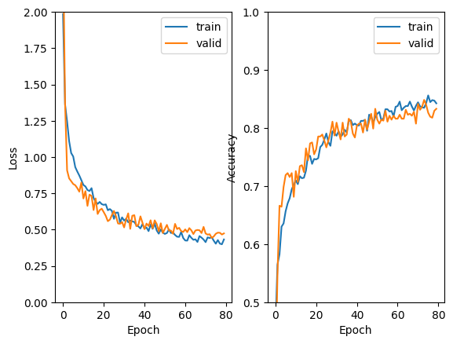

```python
# Visualization of the learning curves

plt.subplot(1, 2, 1)
plt.plot(history.history['loss'])
plt.plot(history.history['val_loss'])
plt.ylim([0.0, 2.0])
plt.xlabel('Epoch')
plt.ylabel('Loss')
plt.legend(['train', 'valid'])

plt.subplot(1, 2, 2)
plt.plot(history.history['accuracy'])
plt.plot(history.history['val_accuracy'])
plt.ylim([0.5, 1.0])
plt.xlabel('Epoch')
plt.ylabel('Accuracy')
plt.legend(['train', 'valid'])
```

```python
net.save("models/B3D2DropA.keras")
```

We achieved a model with zero gap between train and validation accuracy, while retaining nearly the same validation accuracy as the first model we tested. Since the early stopping did not stop the training of the model, we are going to let it train for another bit:

```python
# Train until the early stopping blocks it
# Model training
history = net.fit(train_ds_256,
          epochs=80,
          validation_data=val_ds,
            callbacks=[callback])
```

```python
net.save("models/B3D2DropA2.keras")
```

Lets now test its performances on the test set:

```python
net.evaluate(test_ds)
```

```
[0.4167979061603546, 0.8474114537239075]
```

The test accuracy is of 84.74%, this is even better than the first model we tested.

## Parameters Tuning

We are going to try and tune the parameter of the model. Searching for a combination with better performances:

### Lower LR decay

```python
# Architecture definition LR decay 0.05
inputs = keras.Input((None,None,3))

x = inputs

x = keras.layers.RandomCrop(224, 224)(x)
x = keras.layers.RandomFlip(mode='horizontal')(x)
x = keras.layers.RandomContrast(0.25)(x)

x = keras.layers.Conv2D(64, 3, padding="same")(x)
x = keras.layers.BatchNormalization()(x)
x = keras.layers.Activation("relu")(x)
x = keras.layers.MaxPooling2D(3, strides=3, padding="same")(x)
x = keras.layers.Dropout(0.1)(x)

x = keras.layers.Conv2D(128, 3, padding="same")(x)
x = keras.layers.BatchNormalization()(x)
x = keras.layers.Activation("relu")(x)
x = keras.layers.MaxPooling2D(3, strides=3, padding="same")(x)
x = keras.layers.Dropout(0.1)(x)

x = keras.layers.Conv2D(256, 3, padding="same")(x)
x = keras.layers.BatchNormalization()(x)
x = keras.layers.Activation("relu")(x)
x = keras.layers.Dropout(0.1)(x)

x = keras.layers.GlobalMaxPooling2D()(x)

outputs = keras.layers.Dense(1024, activation="softmax")(x)
x = keras.layers.Dropout(0.2)(x)

outputs = keras.layers.Dense(512, activation="softmax")(x)

outputs = keras.layers.Dense(num_classes, activation="softmax")(x)
net = keras.Model(inputs, outputs)
```

```python
callback = keras.callbacks.EarlyStopping(monitor='val_loss', patience=10)
```

```python
lr_schedule = keras.optimizers.schedules.InverseTimeDecay(
    initial_learning_rate = 0.0005,
    decay_steps = 65,
    decay_rate = 0.05)
optimizer = keras.optimizers.Adam(learning_rate=lr_schedule)
net.compile(loss=keras.losses.categorical_crossentropy,
            optimizer=optimizer,
            metrics=['accuracy'])
```

```python
# Model training
history = net.fit(train_ds_256,
          epochs=80,
          validation_data=val_ds,
            callbacks=[callback])
```

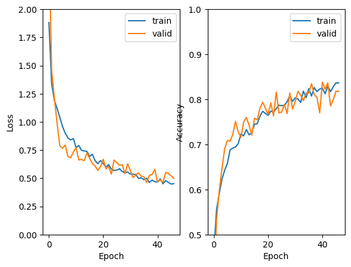

```python
# Visualization of the learning curves

plt.subplot(1, 2, 1)
plt.plot(history.history['loss'])
plt.plot(history.history['val_loss'])
plt.ylim([0.0, 2.0])
plt.xlabel('Epoch')
plt.ylabel('Loss')
plt.legend(['train', 'valid'])

plt.subplot(1, 2, 2)
plt.plot(history.history['accuracy'])
plt.plot(history.history['val_accuracy'])
plt.ylim([0.5, 1.0])
plt.xlabel('Epoch')
plt.ylabel('Accuracy')
plt.legend(['train', 'valid'])
```

```python
net.save("models/B3D2DropAFine1.keras")
```

### Different kernel size (5)

```python
# Architecture definition 5
inputs = keras.Input((None,None,3))

x = inputs

x = keras.layers.RandomCrop(224, 224)(x)
x = keras.layers.RandomFlip(mode='horizontal')(x)
x = keras.layers.RandomContrast(0.25)(x)

x = keras.layers.Conv2D(64, 5, padding="same")(x)
x = keras.layers.BatchNormalization()(x)
x = keras.layers.Activation("relu")(x)
x = keras.layers.MaxPooling2D(3, strides=3, padding="same")(x)
x = keras.layers.Dropout(0.1)(x)

x = keras.layers.Conv2D(128, 5, padding="same")(x)
x = keras.layers.BatchNormalization()(x)
x = keras.layers.Activation("relu")(x)
x = keras.layers.MaxPooling2D(3, strides=3, padding="same")(x)
x = keras.layers.Dropout(0.1)(x)

x = keras.layers.Conv2D(256, 5, padding="same")(x)
x = keras.layers.BatchNormalization()(x)
x = keras.layers.Activation("relu")(x)
x = keras.layers.Dropout(0.1)(x)

x = keras.layers.GlobalMaxPooling2D()(x)

outputs = keras.layers.Dense(1024, activation="softmax")(x)
x = keras.layers.Dropout(0.2)(x)

outputs = keras.layers.Dense(512, activation="softmax")(x)

outputs = keras.layers.Dense(num_classes, activation="softmax")(x)
net = keras.Model(inputs, outputs)
```

```python
callback = keras.callbacks.EarlyStopping(monitor='val_loss', patience=10)
```

```python
lr_schedule = keras.optimizers.schedules.InverseTimeDecay(
    initial_learning_rate = 0.0005,
    decay_steps = 65,
    decay_rate = 0.08)
optimizer = keras.optimizers.Adam(learning_rate=lr_schedule)
net.compile(loss=keras.losses.categorical_crossentropy,
            optimizer=optimizer,
            metrics=['accuracy'])
```

```python
# Model training
history = net.fit(train_ds_256,
          epochs=80,
          validation_data=val_ds,
            callbacks=[callback])
```

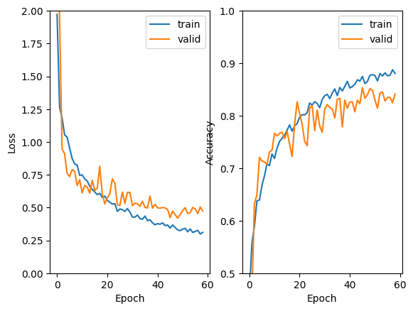

```python
# Visualization of the learning curves

plt.subplot(1, 2, 1)
plt.plot(history.history['loss'])
plt.plot(history.history['val_loss'])
plt.ylim([0.0, 2.0])
plt.xlabel('Epoch')
plt.ylabel('Loss')
plt.legend(['train', 'valid'])

plt.subplot(1, 2, 2)
plt.plot(history.history['accuracy'])
plt.plot(history.history['val_accuracy'])
plt.ylim([0.5, 1.0])
plt.xlabel('Epoch')
plt.ylabel('Accuracy')
plt.legend(['train', 'valid'])
```

```python
net.save("models/B3D2DropAFine2.keras")
```

### Back to the RMSprop optimizer

```python
# Architecture definition
inputs = keras.Input((None,None,3))

x = inputs

x = keras.layers.RandomCrop(224, 224)(x)
x = keras.layers.RandomFlip(mode='horizontal')(x)
x = keras.layers.RandomContrast(0.25)(x)

x = keras.layers.Conv2D(64, 3, padding="same")(x)
x = keras.layers.BatchNormalization()(x)
x = keras.layers.Activation("relu")(x)
x = keras.layers.MaxPooling2D(3, strides=3, padding="same")(x)
x = keras.layers.Dropout(0.1)(x)

x = keras.layers.Conv2D(128, 3, padding="same")(x)
x = keras.layers.BatchNormalization()(x)
x = keras.layers.Activation("relu")(x)
x = keras.layers.MaxPooling2D(3, strides=3, padding="same")(x)
x = keras.layers.Dropout(0.1)(x)

x = keras.layers.Conv2D(256, 3, padding="same")(x)
x = keras.layers.BatchNormalization()(x)
x = keras.layers.Activation("relu")(x)
x = keras.layers.Dropout(0.1)(x)

x = keras.layers.GlobalMaxPooling2D()(x)

outputs = keras.layers.Dense(1024, activation="softmax")(x)
x = keras.layers.Dropout(0.2)(x)

outputs = keras.layers.Dense(512, activation="softmax")(x)

outputs = keras.layers.Dense(num_classes, activation="softmax")(x)
net = keras.Model(inputs, outputs)
```

```python
callback = keras.callbacks.EarlyStopping(monitor='val_loss', patience=10)
```

```python
lr_schedule = keras.optimizers.schedules.InverseTimeDecay(
    initial_learning_rate = 0.0005,
    decay_steps = 65,
    decay_rate = 0.08)
optimizer = keras.optimizers.RMSprop(learning_rate=lr_schedule)
net.compile(loss=keras.losses.categorical_crossentropy,
            optimizer=optimizer,
            metrics=['accuracy'])
```

```python
# Model training
history = net.fit(train_ds_256,
          epochs=80,
          validation_data=val_ds,
            callbacks=[callback])
```

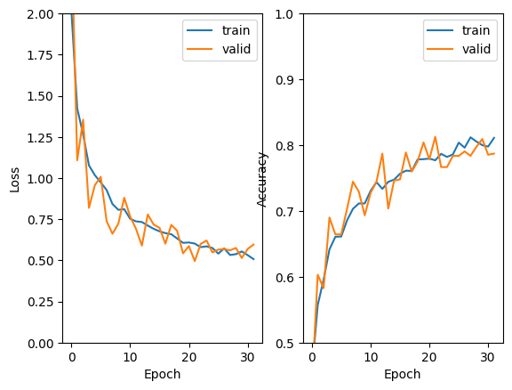

```python
# Visualization of the learning curves

plt.subplot(1, 2, 1)
plt.plot(history.history['loss'])
plt.plot(history.history['val_loss'])
plt.ylim([0.0, 2.0])
plt.xlabel('Epoch')
plt.ylabel('Loss')
plt.legend(['train', 'valid'])

plt.subplot(1, 2, 2)
plt.plot(history.history['accuracy'])
plt.plot(history.history['val_accuracy'])
plt.ylim([0.5, 1.0])
plt.xlabel('Epoch')
plt.ylabel('Accuracy')
plt.legend(['train', 'valid'])
```

```python
net.save("models/B3D2DropAFine3.keras")
```

None of the modification resulted in better performances of the model.

# Segmented Data

Most of the literature on flower recognition with CNN ([Y Liu, 2016](https://ieeexplore.ieee.org/abstract/document/7818296?casa_token=7YGaJAduxPIAAAAA:nqfvofVJMmxCiGYWk4HvJo0MY1iv4gqb0ojuwYHbTp80RRLXm_KXHk2t5yvs0mDmcNsPmhBi), [I Gogul, 2017](https://ieeexplore.ieee.org/abstract/document/8085675?casa_token=lK1wl4fAcE8AAAAA:LVfgp2RSo5o553eFwWKc3Uof1M32t4j0sEQnGBM0jpRsBF7d0jedkr9ibTfA-4XA7Nt6741U), T Nguyen) cites background as one of the biggest problem in flower classification. This is because flowers, because of their environment, tend to have complex background, and that complexity can hurt the performances of a classification model.  
Even if literature cites different segmentation methods to resolve the issue, we are going to utilize a rather "simple" (for what regards application) method: Segment Anything [a Kirillov, 2023](https://openaccess.thecvf.com/content/ICCV2023/html/Kirillov_Segment_Anything_ICCV_2023_paper.html). More specifically, we are going to use [LANG segment anything](https://github.com/luca-medeiros/lang-segment-anything), an open-source project that combines the power of instance segmentation and text prompts to generate masks for specific objects in images. In this way, segmenting our images will be as easy as running the model specifying a prompt like "flower".

```python
# Download the model
%pip install -U git+https://github.com/luca-medeiros/lang-segment-anything.git
```

[output not shown]

[output cut: 16 more lines]

[output not shown]

```python
from PIL import Image
from lang_sam import LangSAM
```

## Two examples

```python
img_path = train_path + 'dandelion/' + os.listdir(train_path + 'dandelion/')[1]
```

```python
model = LangSAM()
image_pil = Image.open(img_path).convert("RGB")
# Define the text prompt
text_prompt = "flower"
masks, boxes, phrases, logits = model.predict(image_pil, text_prompt)
```

```
final text_encoder_type: bert-base-uncased
Model loaded from /root/.cache/huggingface/hub/models--ShilongLiu--GroundingDINO/snapshots/a94c9b567a2a374598f05c584e96798a170c56fb/groundingdino_swinb_cogcoor.pth
 => _IncompatibleKeys(missing_keys=[], unexpected_keys=['label_enc.weight', 'bert.embeddings.position_ids'])
```

```
ndarray (228, 320, 3)
```

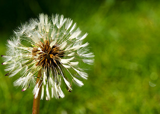

[output not shown]

```python
np.asarray(image_pil)
```

```
ndarray (201, 190, 3)
```

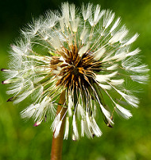

[output not shown]

```python
np.asarray(image_pil)[int(boxes[0][1]):int(boxes[0][1])+int(boxes[0][3]), int(boxes[0][0]):int(boxes[0][0])+int(boxes[0][2])]
```

```python
img_path = train_path + 'dandelion/' + os.listdir(train_path + 'dandelion/')[2]
image_pil = Image.open(img_path).convert("RGB")
```

```
ndarray (241, 320, 3)
```

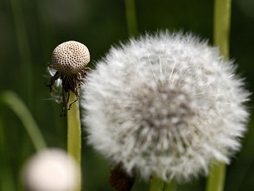

[output not shown]

```python
np.asarray(image_pil)
```

```python
masks, boxes, phrases, logits = model.predict(image_pil, text_prompt)
```

```
ndarray (206, 221, 3)
```

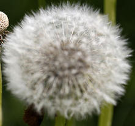

[output not shown]

```python
np.asarray(image_pil)[int(boxes[0][1]):int(boxes[0][1])+int(boxes[0][3]), int(boxes[0][0]):int(boxes[0][0])+int(boxes[0][2])]
```

## Segment Train and Test

Now, we apply the segmentation to all of our data

```python
from tqdm import tqdm
import warnings
import os
import numpy as np
from PIL import Image
import matplotlib.pyplot as plt
import re
import random
warnings.filterwarnings("ignore")
classes = os.listdir(train_path)
```

```python
classes
```

```
['dandelion', 'tulips', 'daisy', 'sunflowers', 'roses']
```

### Train

```python
base_path = 'C:/Users/david/Desktop/DeepLearning/flower_photos/Train/'
save_path = 'C:/Users/david/Desktop/DeepLearning/flower_cropped/Train/'
```

```python
for flower_class in classes:
  img_list = os.listdir(base_path + flower_class)
  already_saved = []
  for el in os.listdir(save_path + flower_class):
    # remove '.jpg'
    el = ''.join(el.split('.')[:-1])
    if el[-2:] == '_0':
      already_saved.append(el[:-2] + '.jpg')
  for img_path in tqdm(img_list):
    if img_path in already_saved:
      continue
    image_pil = Image.open(base_path + flower_class + '/' + img_path).convert("RGB")
    masks, boxes, phrases, logits = model.predict(image_pil, text_prompt)
    for i in range(len(boxes)):
      cropped_img = np.asarray(image_pil)[int(boxes[i][1]):int(boxes[i][1])+int(boxes[i][3]), int(boxes[i][0]):int(boxes[i][0])+int(boxes[i][2])]
      final_img = Image.fromarray(cropped_img)
      final_img.save(save_path + flower_class + '/' + ''.join(img_path.split('.')[:-1]) + '_' + str(i) + '.jpg')
```

### Test

```python
base_path = 'C:/Users/david/Desktop/DeepLearning/flower_photos/Test/'
save_path = 'C:/Users/david/Desktop/DeepLearning/flower_cropped/Test/'
```

```python
for flower_class in classes:
  img_list = os.listdir(base_path + flower_class)
  already_saved = []
  for el in os.listdir(save_path + flower_class):
    # remove '.jpg'
    el = ''.join(el.split('.')[:-1])
    if el[-2:] == '_0':
      already_saved.append(el[:-2] + '.jpg')
  for img_path in tqdm(img_list):
    if img_path in already_saved:
      continue
    image_pil = Image.open(base_path + flower_class + '/' + img_path).convert("RGB")
    masks, boxes, phrases, logits = model.predict(image_pil, text_prompt)
    for i in range(len(boxes)):
      # There could be more than a flower in a image!
      cropped_img = np.asarray(image_pil)[int(boxes[i][1]):int(boxes[i][1])+int(boxes[i][3]), int(boxes[i][0]):int(boxes[i][0])+int(boxes[i][2])]
      final_img = Image.fromarray(cropped_img)
      final_img.save(save_path + flower_class + '/' + ''.join(img_path.split('.')[:-1]) + '_' + str(i) + '.jpg')
```

## Dimensionality check

Let's check that there isn't anything strange with the pictures.

While segmenting the images, we noticed that some pciture have strange dimensions. Here is an example:

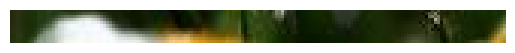

```python
image_pil = Image.open(train_path + 'daisy/102841525_bd6628ae3c_16.jpg').convert("RGB")

# Display the image
plt.imshow(np.asarray(image_pil))
plt.axis('off')  # Turn off axis
plt.show()
```

```python
clas_diz['daisy']['102841525_bd6628ae3c_16.jpg']
```

```
(11, 165, 3)
```

To avoid that this type of images get into the training dataset, we are going to remove every image that has one dimension that is shorter than 15pixels (this is an arbitrary measure).

```python
# Get the dimensions of all images in train set
clas_diz = {}
for clas in classes:
    diz = {}
    for img_path in tqdm(os.listdir(train_path + clas)):
        image_pil = Image.open(train_path + clas + '/' + img_path).convert("RGB")
        diz[img_path] = np.asarray(image_pil).shape
    clas_diz[clas] = diz
```

```python
test_path = base_path + 'Test/'
# Get the dimensions of all images in test set
clas_diz_test = {}
for clas in classes:
    diz = {}
    for img_path in tqdm(os.listdir(test_path + clas)):
        image_pil = Image.open(test_path + clas + '/' + img_path).convert("RGB")
        diz[img_path] = np.asarray(image_pil).shape
    clas_diz_test[clas] = diz
```

```python
delete_diz = clas_diz.copy()
```

```python
# Insert all of the training images with a dimension lower that 15px into the "delete_diz" dictionary
delete_diz = {}
for clas in classes:
    delete_diz[clas] = []
    for key, value in clas_diz[clas].items():
        if value[0] <= 15 or value[1] <= 15:
            delete_diz[clas].append(key)
```

```python
# How many images are we going to delete from training set?
diz = {}
for clas in classes:
    diz[clas] = len(delete_diz[clas])

diz
```

```
{'daisy': 69, 'dandelion': 26, 'roses': 14, 'sunflowers': 53, 'tulips': 68}
```

```python
# Delete all the images in the "delete_diz" dictionary
for clas in classes:
    for img_path in delete_diz[clas]:
        os.remove(train_path + clas + '/' + img_path)
```

```python
delete_diz = clas_diz_test.copy()
```

```python
# Insert all of the test images with a dimension lower that 15px into the "delete_diz" dictionary
delete_diz = {}
for clas in classes:
    delete_diz[clas] = []
    for key, value in clas_diz_test[clas].items():
        if value[0] <= 15 or value[1] <= 15:
            delete_diz[clas].append(key)
```

```python
# How many images are we going to delete from test set?
diz = {}
for clas in classes:
    diz[clas] = len(delete_diz[clas])

diz
```

```
{'daisy': 17, 'dandelion': 7, 'roses': 2, 'sunflowers': 18, 'tulips': 17}
```

```python
# Delete all the images in the "delete_diz" dictionary
for clas in classes:
    for img_path in delete_diz[clas]:
        os.remove(test_path + clas + '/' + img_path)
```

### How many images have we generated?

Since in each picture there can be more than one flower, the dimensinoality of the dataset have changed, let's check how much.

```python
train_path = 'C:/Users/david/Desktop/DeepLearning/flower_cropped/Train/'
subD = os.listdir(train_path)
dizTrain = {}
# For each class subdirectory, insert in the dictionary dizTrain the number of element in that subdirectory
for dir in subD:
    dizTrain[dir] = len(os.listdir(train_path + dir))
```

```python
# Number of observations of each class in train set
dizTrain
```

```
{'daisy': 2477,
 'dandelion': 1275,
 'roses': 1504,
 'sunflowers': 2229,
 'tulips': 2986}
```

```python
subD = os.listdir(test_path)
dizTest = {}
# For each class subdirectory, insert in the dictionary dizTrain the number of element in that subdirectory
for dir in subD:
    dizTest[dir] = len(os.listdir(test_path + dir))
```

```python
# Number of observations of each class in train set
dizTest
```

```
{'daisy': 682,
 'dandelion': 392,
 'roses': 261,
 'sunflowers': 568,
 'tulips': 671}
```

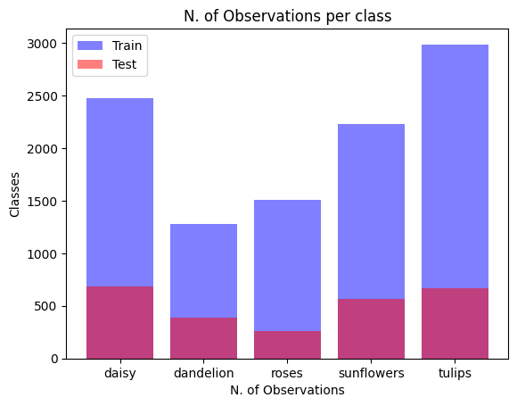

```python
plt.bar(dizTrain.keys(), dizTrain.values(), color='b', alpha=0.5, label='Train')
plt.bar(dizTest.keys(), dizTest.values(), color='r', alpha=0.5, label='Test')

# Adding labels and title
plt.xlabel('N. of Observations')
plt.ylabel('Classes')
plt.title('N. of Observations per class')
plt.legend()

# Show plot
plt.show()
```

The segmentation increased the difference between the classes. We are firstly going to run the models with this data, then we are going to try balancing them.

### Build the test dataset

For what regards the test set, we now have multiple cropped picture coming from the same original image. This could cause some problem in the evaluation of the model, since there would be some original image that appears more times then other in the test set (those with more flowers detected from the segmentation model).  
To solve this issue we are going to build 3 different test sets, one with its own pro and cons:

1. The original test set with uncropped images. It is going to be used to evaluate the model performances to generalized even to the raw, unsegmented, original images.
2. The unbalances test set. It is going to be used to evaluate the model performances on all the flowers that the segmented model has detected.
3. A balanced segmented test set. Composed of one segmented image for each original picture. This resolves the problem of the unbalanced test set (there will be only one segmented image for each original picture), but it does so by selecting one random segmented image (the first one for simplicity) from each original picture, and this adds randomness.

```python
test_path_balanced = base_path + 'TestBalanced/'
```

```python
classes
```

```
['daisy', 'dandelion', 'roses', 'sunflowers', 'tulips']
```

```python
# We are simply going to mantain only the first segmented image for each original picture
# That is, we are going to mantain all those images that end with "_0.jpg"
for clas in classes:
    for img in os.listdir(test_path_balanced + clas):
        if img[-6:] != '_0.jpg':
            os.remove(test_path_balanced + clas + '/' + img)
```

```python
# Check how many images for each class
subD = os.listdir(test_path_balanced)
dizTestB = {}
# For each class subdirectory, insert in the dictionary dizTrain the number of element in that subdirectory
for dir in subD:
    dizTestB[dir] = len(os.listdir(test_path_balanced + dir))
dizTestB
```

```
{'daisy': 125,
 'dandelion': 196,
 'roses': 106,
 'sunflowers': 138,
 'tulips': 167}
```

### Load test data

```python
# First test set (original)
base_path = 'C:/Users/david/Desktop/DeepLearning/flower_photos/'
test_ds = keras.preprocessing.image_dataset_from_directory(base_path +'Test',
                                                            image_size=(224,224),
                                                            batch_size=128,
                                                            label_mode='categorical',
                                                            shuffle=False,
                                                            seed=1)
# Second test set (segmented)
base_path = 'C:/Users/david/Desktop/DeepLearning/flower_cropped/'
test_ds_cropped = keras.preprocessing.image_dataset_from_directory(base_path +'Test',
                                                            image_size=(224,224),
                                                            batch_size=128,
                                                            label_mode='categorical',
                                                            shuffle=False,
                                                            seed=1)

# Third test set (segmented balanced)
test_ds_cropped_balanced = keras.preprocessing.image_dataset_from_directory(base_path +'TestBalanced',
                                                            image_size=(224,224),
                                                            batch_size=128,
                                                            label_mode='categorical',
                                                            shuffle=False,
                                                            seed=1)
```

```
Found 734 files belonging to 5 classes.
Found 2574 files belonging to 5 classes.
Found 732 files belonging to 5 classes.
```

Note: the 2 photo difference between original and segmented balanced is probably due to the fact that the segmentation model did not find any flower to segment in those two images, thus not producing any segmented image.

# CNN with Segmented Data

```python
base_path = 'C:/Users/david/Desktop/DeepLearning/flower_cropped/'

train_ds = keras.preprocessing.image_dataset_from_directory(base_path + 'Train',
                                                            image_size=(224,224),
                                                            batch_size=32,
                                                            label_mode='categorical',
                                                            subset='training',
                                                            validation_split = 0.3,
                                                            shuffle=True,
                                                            seed=1)

val_ds = keras.preprocessing.image_dataset_from_directory(base_path + 'Train',
                                                            image_size=(224,224),
                                                            batch_size=32,
                                                            label_mode='categorical',
                                                            subset='validation',
                                                            validation_split = 0.3,
                                                            shuffle=True,
                                                            seed=1)

test_ds_cropped = keras.preprocessing.image_dataset_from_directory(base_path +'Test',
                                                            image_size=(224,224),
                                                            batch_size=128,
                                                            label_mode='categorical',
                                                            shuffle=False,
                                                            seed=1)

# Data loader with (slightly) larger images
train_ds_256 = keras.preprocessing.image_dataset_from_directory( base_path + 'Train',
                                                            image_size=(256,256),
                                                            batch_size=32,
                                                            label_mode='categorical',
                                                            subset='training',
                                                            validation_split = 0.3,
                                                            shuffle=True,
                                                            seed=1)

num_classes = 5
```

[output not shown]

```python
train_ds_256.file_paths == train_ds.file_paths
```

```
True
```

## Unbalanced Data

### First model

We are firstly going to evaluate the performances of the first model of the two that achieved the best performances with the non-segmented images:

```python
# Architecture definition of first model.
inputs = keras.Input((None,None,3))

x = inputs

x = keras.layers.RandomCrop(224, 224)(x)
x = keras.layers.RandomFlip(mode='horizontal')(x)
x = keras.layers.RandomContrast(0.25)(x)

x = keras.layers.Conv2D(32, 3, padding="same", kernel_regularizer=tf.keras.regularizers.l2(0.001))(x)
x = keras.layers.BatchNormalization()(x)
x = keras.layers.Activation("relu")(x)
x = keras.layers.MaxPooling2D(3, strides=3, padding="same")(x)

x = keras.layers.Conv2D(64, 3, padding="same", kernel_regularizer=tf.keras.regularizers.l2(0.001))(x)
x = keras.layers.BatchNormalization()(x)
x = keras.layers.Activation("relu")(x)
x = keras.layers.MaxPooling2D(3, strides=3, padding="same")(x)

x = keras.layers.Conv2D(128, 3, padding="same", kernel_regularizer=tf.keras.regularizers.l2(0.001))(x)
x = keras.layers.BatchNormalization()(x)
x = keras.layers.Activation("relu")(x)

x = keras.layers.GlobalMaxPooling2D()(x)

outputs = keras.layers.Dense(num_classes, activation="softmax", kernel_regularizer=tf.keras.regularizers.l2(0.001))(x)
net = keras.Model(inputs, outputs)
```

```python
callback = keras.callbacks.EarlyStopping(monitor='val_loss', patience=10)
```

```python
# Compile the model for training
net.compile(loss=keras.losses.categorical_crossentropy,
            optimizer=keras.optimizers.RMSprop(learning_rate=0.0001),
            metrics=['accuracy'])
```

```python
# Model training (v4)
history = net.fit(train_ds_256,
          epochs=80,
          validation_data=val_ds,
          callbacks = [callback])
```

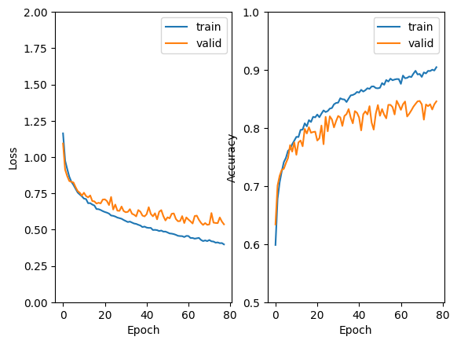

```python
# Visualization of the learning curves

plt.subplot(1, 2, 1)
plt.plot(history.history['loss'])
plt.plot(history.history['val_loss'])
plt.ylim([0.0, 2.0])
plt.xlabel('Epoch')
plt.ylabel('Loss')
plt.legend(['train', 'valid'])

plt.subplot(1, 2, 2)
plt.plot(history.history['accuracy'])
plt.plot(history.history['val_accuracy'])
plt.ylim([0.5, 1.0])
plt.xlabel('Epoch')
plt.ylabel('Accuracy')
plt.legend(['train', 'valid'])
```

```python
net.save('models/Segmented1RMS.keras')
```

```python
# Evaluate on the 3 test dataset:
net = keras.models.load_model("models/Segmented1RMS.keras")
net.evaluate(test_ds)
net.evaluate(test_ds_cropped)
net.evaluate(test_ds_cropped_balanced)
```

```
[0.6117007732391357, 0.8333333134651184]
```

### Second model

The second model between the two best built with the unsegmented data:

```python
# Architecture definition
inputs = keras.Input((None,None,3))

x = inputs

x = keras.layers.RandomCrop(224, 224)(x)
x = keras.layers.RandomFlip(mode='horizontal')(x)
x = keras.layers.RandomContrast(0.25)(x)

x = keras.layers.Conv2D(64, 3, padding="same")(x)
x = keras.layers.BatchNormalization()(x)
x = keras.layers.Activation("relu")(x)
x = keras.layers.MaxPooling2D(3, strides=3, padding="same")(x)
x = keras.layers.Dropout(0.1)(x)

x = keras.layers.Conv2D(128, 3, padding="same")(x)
x = keras.layers.BatchNormalization()(x)
x = keras.layers.Activation("relu")(x)
x = keras.layers.MaxPooling2D(3, strides=3, padding="same")(x)
x = keras.layers.Dropout(0.1)(x)

x = keras.layers.Conv2D(256, 3, padding="same")(x)
x = keras.layers.BatchNormalization()(x)
x = keras.layers.Activation("relu")(x)
x = keras.layers.Dropout(0.1)(x)

x = keras.layers.GlobalMaxPooling2D()(x)

outputs = keras.layers.Dense(1024, activation="softmax")(x)
x = keras.layers.Dropout(0.2)(x)

outputs = keras.layers.Dense(512, activation="softmax")(x)

outputs = keras.layers.Dense(num_classes, activation="softmax")(x)
net = keras.Model(inputs, outputs)
```

```python
callback = keras.callbacks.EarlyStopping(monitor='val_loss', patience=10)
```

```python
lr_schedule = keras.optimizers.schedules.InverseTimeDecay(
    initial_learning_rate = 0.0005,
    decay_steps = 65,
    decay_rate = 0.08)
optimizer = keras.optimizers.Adam(learning_rate=lr_schedule)
net.compile(loss=keras.losses.categorical_crossentropy,
            optimizer=optimizer,
            metrics=['accuracy'])
```

```python
# Model training
history = net.fit(train_ds_256,
          epochs=80,
          validation_data=val_ds,
            callbacks=[callback])
```

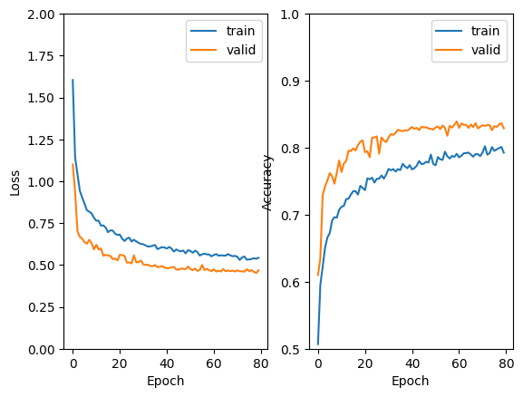

```python
# Visualization of the learning curves

plt.subplot(1, 2, 1)
plt.plot(history.history['loss'])
plt.plot(history.history['val_loss'])
plt.ylim([0.0, 2.0])
plt.xlabel('Epoch')
plt.ylabel('Loss')
plt.legend(['train', 'valid'])

plt.subplot(1, 2, 2)
plt.plot(history.history['accuracy'])
plt.plot(history.history['val_accuracy'])
plt.ylim([0.5, 1.0])
plt.xlabel('Epoch')
plt.ylabel('Accuracy')
plt.legend(['train', 'valid'])
```

```python
net.save('models/Segmented2RMS.keras')
```

```python
net.evaluate(test_ds)
```

```
[0.5306099057197571, 0.8119891285896301]
```

```python
net.evaluate(test_ds_cropped)
```

```
[0.5543912053108215, 0.810800313949585]
```

```python
net.evaluate(test_ds_cropped_balanced)
```

```
[0.44818899035453796, 0.8469945192337036]
```

None of the three accuracy resulted to be higher than the test accuracy we achieved with the model with unsegmented data (84.74%).

### Lowering the Dropout rates

Since the dropout rates we set for the model with unsegmented data seems to be excessive now, we are going to retry this same architecture on the segmented data, but changing the DropOut rates. In particular, we are going to remove the Dropout Layer from the last 1024 Dense layer.

```python
# Architecture definition
inputs = keras.Input((None,None,3))

x = inputs

x = keras.layers.RandomCrop(224, 224)(x)
x = keras.layers.RandomFlip(mode='horizontal')(x)
x = keras.layers.RandomContrast(0.25)(x)

x = keras.layers.Conv2D(64, 3, padding="same")(x)
x = keras.layers.BatchNormalization()(x)
x = keras.layers.Activation("relu")(x)
x = keras.layers.MaxPooling2D(3, strides=3, padding="same")(x)
x = keras.layers.Dropout(0.1)(x)

x = keras.layers.Conv2D(128, 3, padding="same")(x)
x = keras.layers.BatchNormalization()(x)
x = keras.layers.Activation("relu")(x)
x = keras.layers.MaxPooling2D(3, strides=3, padding="same")(x)
x = keras.layers.Dropout(0.1)(x)

x = keras.layers.Conv2D(256, 3, padding="same")(x)
x = keras.layers.BatchNormalization()(x)
x = keras.layers.Activation("relu")(x)
x = keras.layers.Dropout(0.1)(x)

x = keras.layers.GlobalMaxPooling2D()(x)

outputs = keras.layers.Dense(1024, activation="softmax")(x)

outputs = keras.layers.Dense(512, activation="softmax")(x)

outputs = keras.layers.Dense(num_classes, activation="softmax")(x)
net = keras.Model(inputs, outputs)
```

```python
early_stopping = keras.callbacks.EarlyStopping(monitor='val_loss', patience=10)
```

```python
checkpoint_filepath = "/Checkpoint"
checkpoint_callback = tf.keras.callbacks.ModelCheckpoint(
    filepath=checkpoint_filepath,
    monitor='val_accuracy',
    mode='max')
```

```python
lr_schedule = keras.optimizers.schedules.InverseTimeDecay(
    initial_learning_rate = 0.0005,
    decay_steps = 65,
    decay_rate = 0.08)
optimizer = keras.optimizers.Adam(learning_rate=lr_schedule)
net.compile(loss=keras.losses.categorical_crossentropy,
            optimizer=optimizer,
            metrics=['accuracy'])
```

```python
# Model training
history = net.fit(train_ds_256,
          epochs=80,
          validation_data=val_ds,
            callbacks=[early_stopping, checkpoint_callback])
```

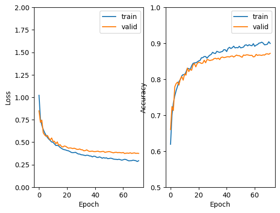

```python
# Visualization of the learning curves

plt.subplot(1, 2, 1)
plt.plot(history.history['loss'])
plt.plot(history.history['val_loss'])
plt.ylim([0.0, 2.0])
plt.xlabel('Epoch')
plt.ylabel('Loss')
plt.legend(['train', 'valid'])

plt.subplot(1, 2, 2)
plt.plot(history.history['accuracy'])
plt.plot(history.history['val_accuracy'])
plt.ylim([0.5, 1.0])
plt.xlabel('Epoch')
plt.ylabel('Accuracy')
plt.legend(['train', 'valid'])
```

```python
net.save('models/Segmented3.keras')
```

```python
net.evaluate(test_ds)
```

```
[0.5025416612625122, 0.8256130814552307]
```

```python
net.evaluate(test_ds_cropped)
```

```
[0.508144736289978, 0.8302253484725952]
```

```python
net.evaluate(test_ds_cropped_balanced)
```

```
[0.4213521182537079, 0.8483606576919556]
```

The accuracy achieved on the test set is notably lower than the accuracy achieved in the validation set, this could be signed of overfitting. The only train accuracy that appears to be higher than the one achieved in the original model (84.74%) is the one achieved in the balanced and segmented test set (84.84%). This could signal better performances on the model if applied to data that is already segmented. Though, the gap is not big.

## Balancing the dataset

As we said before, the classes in this segmented dataset are unbalanced, we are going to leave dandelion to 1275, and subset every other flower class. Subsetting is not easy, since we have to make sure that each original image is in the subset.

```python
# Original dimensions of classes
diz = {}
for clas in classes:
    diz[clas] = len(os.listdir(train_path + clas))

diz
```

```
{'daisy': 2477,
 'dandelion': 1275,
 'roses': 1504,
 'sunflowers': 2229,
 'tulips': 2986}
```

```python
subsets = {}
for clas in classes:
    lst = []
    listdir = os.listdir(train_path + clas)
    if clas == 'dandelion':
        subsets[clas] = listdir
        continue
    uniques = []
    for img_path in listdir:
        # Search for the unique images
        unique = re.findall(r'(.*)_\d+.jpg', img_path)[0]
        uniques.append(unique)
    uniques = set(uniques)
    for unique in uniques:
        batch = []
        for img_path in listdir:
            if unique in img_path:
                batch.append(img_path)
        # Prendine uno a caso da batch
        random_element = random.choice(batch)
        # Aggiungilo a lst
        lst.append(random_element)
        # Rimuovilo da listdir
        listdir.remove(random_element)
    # Ora siamo sicuri di avere un alemenento per ciascuna foto, prendiamo gli altri casualmenti da quelli rimasti in listdir
    lst = lst + random.sample(listdir, 1275 - len(lst))
    # Save it in the dictionary
    subsets[clas] = lst
```

```python
diz = {}
for clas in classes:
    diz[clas] = len(subsets[clas])
diz
```

```
{'daisy': 1275,
 'dandelion': 1275,
 'roses': 1275,
 'sunflowers': 1275,
 'tulips': 1275}
```

```python
train_balanced_path = 'C:/Users/david/Desktop/DeepLearning/flower_cropped/TrainBalanced/'
# Remove files that are not in the dictionary
for clas in classes:
    for img in os.listdir(train_balanced_path + clas):
        if img not in subsets[clas]:
            os.remove(train_balanced_path + clas + '/' + img)
```

```python
base_path = 'C:/Users/david/Desktop/DeepLearning/flower_cropped/'

train_ds = keras.preprocessing.image_dataset_from_directory(base_path + 'TrainBalanced',
                                                            image_size=(224,224),
                                                            batch_size=32,
                                                            label_mode='categorical',
                                                            subset='training',
                                                            validation_split = 0.3,
                                                            shuffle=True,
                                                            seed=1)

val_ds = keras.preprocessing.image_dataset_from_directory(base_path + 'TrainBalanced',
                                                            image_size=(224,224),
                                                            batch_size=32,
                                                            label_mode='categorical',
                                                            subset='validation',
                                                            validation_split = 0.3,
                                                            shuffle=True,
                                                            seed=1)

# Data loader with (slightly) larger images
train_ds_256 = keras.preprocessing.image_dataset_from_directory(base_path + 'TrainBalanced',
                                                            image_size=(256,256),
                                                            batch_size=32,
                                                            label_mode='categorical',
                                                            subset='training',
                                                            validation_split = 0.3,
                                                            shuffle=True,
                                                            seed=1)

num_classes = 5
```

```
Found 6375 files belonging to 5 classes.
Using 4463 files for training.
Found 6375 files belonging to 5 classes.
Using 1912 files for validation.
Found 6375 files belonging to 5 classes.
Using 4463 files for training.
```

# CNNs with Segmented and Balanced data

## First Model

Testing the performances of the first of the two best models:

```python
# Architecture definition
inputs = keras.Input((None,None,3))

x = inputs

x = keras.layers.RandomCrop(224, 224)(x)
x = keras.layers.RandomFlip(mode='horizontal')(x)
x = keras.layers.RandomContrast(0.25)(x)

x = keras.layers.Conv2D(32, 3, padding="same")(x)
x = keras.layers.BatchNormalization()(x)
x = keras.layers.Activation("relu")(x)
x = keras.layers.MaxPooling2D(3, strides=3, padding="same")(x)

x = keras.layers.Conv2D(64, 3, padding="same")(x)
x = keras.layers.BatchNormalization()(x)
x = keras.layers.Activation("relu")(x)
x = keras.layers.MaxPooling2D(3, strides=3, padding="same")(x)
x = keras.layers.Dropout(0.1)(x)

x = keras.layers.Conv2D(128, 3, padding="same")(x)
x = keras.layers.BatchNormalization()(x)
x = keras.layers.Activation("relu")(x)
x = keras.layers.Dropout(0.2)(x)

x = keras.layers.GlobalMaxPooling2D()(x)

outputs = keras.layers.Dense(num_classes, activation="softmax")(x)
net = keras.Model(inputs, outputs)
```

```python
callback = keras.callbacks.EarlyStopping(monitor='val_loss', patience=10)
```

```python
lr_schedule = keras.optimizers.schedules.InverseTimeDecay(
    initial_learning_rate = 0.0005,
    decay_steps = 65,
    decay_rate = 0.08)
optimizer = keras.optimizers.Adam(learning_rate=lr_schedule)
net.compile(loss=keras.losses.categorical_crossentropy,
            optimizer=optimizer,
            metrics=['accuracy'])
```

```python
# Model training
history = net.fit(train_ds_256,
          epochs=80,
          validation_data=val_ds,
            callbacks=[callback])
```

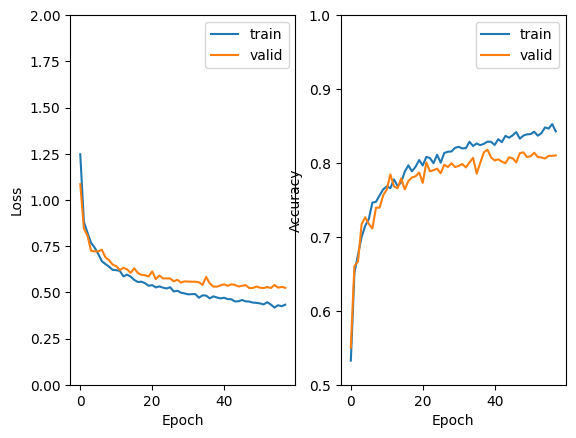

```python
# Visualization of the learning curves

plt.subplot(1, 2, 1)
plt.plot(history.history['loss'])
plt.plot(history.history['val_loss'])
plt.ylim([0.0, 2.0])
plt.xlabel('Epoch')
plt.ylabel('Loss')
plt.legend(['train', 'valid'])

plt.subplot(1, 2, 2)
plt.plot(history.history['accuracy'])
plt.plot(history.history['val_accuracy'])
plt.ylim([0.5, 1.0])
plt.xlabel('Epoch')
plt.ylabel('Accuracy')
plt.legend(['train', 'valid'])
```

```python
net.save('models/BalancedSegmentv1.keras')
```

```python
net = keras.models.load_model("models/BalancedSegmentv1.keras")
net.evaluate(test_ds)
net.evaluate(test_ds_cropped)
net.evaluate(test_ds_cropped_balanced)
```

```
[0.49677494168281555, 0.8278688788414001]
```

## Second Model

Testing the performances of the second of the two best models:

```python
# Architecture definition
inputs = keras.Input((None,None,3))

x = inputs

x = keras.layers.RandomCrop(224, 224)(x)
x = keras.layers.RandomFlip(mode='horizontal')(x)
x = keras.layers.RandomContrast(0.25)(x)

x = keras.layers.Conv2D(64, 3, padding="same")(x)
x = keras.layers.BatchNormalization()(x)
x = keras.layers.Activation("relu")(x)
x = keras.layers.MaxPooling2D(3, strides=3, padding="same")(x)
x = keras.layers.Dropout(0.1)(x)

x = keras.layers.Conv2D(128, 3, padding="same")(x)
x = keras.layers.BatchNormalization()(x)
x = keras.layers.Activation("relu")(x)
x = keras.layers.MaxPooling2D(3, strides=3, padding="same")(x)
x = keras.layers.Dropout(0.1)(x)

x = keras.layers.Conv2D(256, 3, padding="same")(x)
x = keras.layers.BatchNormalization()(x)
x = keras.layers.Activation("relu")(x)
x = keras.layers.Dropout(0.1)(x)

x = keras.layers.GlobalMaxPooling2D()(x)

outputs = keras.layers.Dense(1024, activation="softmax")(x)
x = keras.layers.Dropout(0.2)(x)

outputs = keras.layers.Dense(512, activation="softmax")(x)

outputs = keras.layers.Dense(num_classes, activation="softmax")(x)
net = keras.Model(inputs, outputs)
```

```python
callback = keras.callbacks.EarlyStopping(monitor='val_loss', patience=10)
```

```python
lr_schedule = keras.optimizers.schedules.InverseTimeDecay(
    initial_learning_rate = 0.0005,
    decay_steps = 65,
    decay_rate = 0.08)
optimizer = keras.optimizers.Adam(learning_rate=lr_schedule)
net.compile(loss=keras.losses.categorical_crossentropy,
            optimizer=optimizer,
            metrics=['accuracy'])
```

```python
# Model training
history = net.fit(train_ds_256,
          epochs=80,
          validation_data=val_ds,
            callbacks=[callback])
```

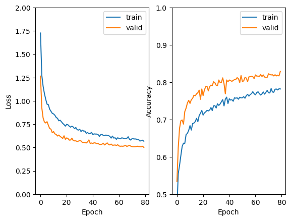

```python
# Visualization of the learning curves

plt.subplot(1, 2, 1)
plt.plot(history.history['loss'])
plt.plot(history.history['val_loss'])
plt.ylim([0.0, 2.0])
plt.xlabel('Epoch')
plt.ylabel('Loss')
plt.legend(['train', 'valid'])

plt.subplot(1, 2, 2)
plt.plot(history.history['accuracy'])
plt.plot(history.history['val_accuracy'])
plt.ylim([0.5, 1.0])
plt.xlabel('Epoch')
plt.ylabel('Accuracy')
plt.legend(['train', 'valid'])
```

```python
net.save('models/BalancedSegmented2.keras')
```

```python
net.evaluate(test_ds)
```

```
[0.5200757384300232, 0.8106266856193542]
```

```python
net.evaluate(test_ds_cropped)
```

```
[0.5853006839752197, 0.8045843243598938]
```

```python
net.evaluate(test_ds_cropped_balanced)
```

```
[0.4550371766090393, 0.8319672346115112]
```

None of the three accuracy resulted to be higher than the test accuracy we achieved with the same model applied to unsegmented data (84.74%). Also, the balancing of the dataset did not seem to increase the performance of the model, since the performances decreased on all the test sets.

### Lowering the Dropout rates

As we did with the unbalanced data, since the dropout rates we set for the model with unsegmented data seems to be excessive now, we are going to retry this same architecture on the segmented and balanced data data, but changing the DropOut rates. In particular, we are going to remove the Dropout Layer from the last 1024 Dense layer.

```python
# Architecture definition
inputs = keras.Input((None,None,3))

x = inputs

x = keras.layers.RandomCrop(224, 224)(x)
x = keras.layers.RandomFlip(mode='horizontal')(x)
x = keras.layers.RandomContrast(0.25)(x)

x = keras.layers.Conv2D(64, 3, padding="same")(x)
x = keras.layers.BatchNormalization()(x)
x = keras.layers.Activation("relu")(x)
x = keras.layers.MaxPooling2D(3, strides=3, padding="same")(x)
x = keras.layers.Dropout(0.1)(x)

x = keras.layers.Conv2D(128, 3, padding="same")(x)
x = keras.layers.BatchNormalization()(x)
x = keras.layers.Activation("relu")(x)
x = keras.layers.MaxPooling2D(3, strides=3, padding="same")(x)
x = keras.layers.Dropout(0.1)(x)

x = keras.layers.Conv2D(256, 3, padding="same")(x)
x = keras.layers.BatchNormalization()(x)
x = keras.layers.Activation("relu")(x)
x = keras.layers.Dropout(0.1)(x)

x = keras.layers.GlobalMaxPooling2D()(x)

outputs = keras.layers.Dense(1024, activation="softmax")(x)

outputs = keras.layers.Dense(512, activation="softmax")(x)

outputs = keras.layers.Dense(num_classes, activation="softmax")(x)
net = keras.Model(inputs, outputs)
```

```python
early_stopping = keras.callbacks.EarlyStopping(monitor='val_loss', patience=10)
```

```python
checkpoint_filepath = "/content/gdrive/MyDrive/Deep Learning Project/Checkpoint3"
checkpoint_callback = tf.keras.callbacks.ModelCheckpoint(
    filepath=checkpoint_filepath,
    monitor='val_accuracy',
    mode='max')
```

```python
lr_schedule = keras.optimizers.schedules.InverseTimeDecay(
    initial_learning_rate = 0.0005,
    decay_steps = 65,
    decay_rate = 0.08)
optimizer = keras.optimizers.Adam(learning_rate=lr_schedule)
net.compile(loss=keras.losses.categorical_crossentropy,
            optimizer=optimizer,
            metrics=['accuracy'])
```

```python
# Model training
history = net.fit(train_ds_256,
          epochs=80,
          validation_data=val_ds,
            callbacks=[early_stopping, checkpoint_callback])
```

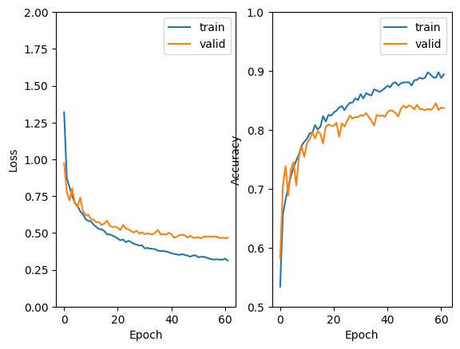

```python
# Visualization of the learning curves

plt.subplot(1, 2, 1)
plt.plot(history.history['loss'])
plt.plot(history.history['val_loss'])
plt.ylim([0.0, 2.0])
plt.xlabel('Epoch')
plt.ylabel('Loss')
plt.legend(['train', 'valid'])

plt.subplot(1, 2, 2)
plt.plot(history.history['accuracy'])
plt.plot(history.history['val_accuracy'])
plt.ylim([0.5, 1.0])
plt.xlabel('Epoch')
plt.ylabel('Accuracy')
plt.legend(['train', 'valid'])
```

```python
net.save("/content/gdrive/MyDrive/Deep Learning Project/Segmentedv5.keras")
```

```python
net.evaluate(test_ds)
```

```
[0.5475756525993347, 0.807901918888092]
```

```python
net.evaluate(test_ds_cropped)
```

```
[0.5767860412597656, 0.810800313949585]
```

```python
net.evaluate(test_ds_cropped_balanced)
```

```
[0.4618443548679352, 0.8306010961532593]
```

None of the three accuracy resulted to be higher than the test accuracy we achieved with the same model applied to unsegmented data (84.74%). Also, the balancing of the dataset did not seem to increase the performance of the model, since the performances decreased on all the test sets.